# NDFS Synthesis Manuscript: Chlorophyll analysis

Model selection

Dave Bosworth

October 30, 2023

# Purpose

Explore and analyze the continuous chlorophyll data to be included in the NDFS synthesis manuscript. We will attempt to fit multiple models to the data set and use a model selection process to determine the best one. At a minimum the model will contain the three categorical variables (Year, Station, and Flow Pulse Period) and optionally a term to account for seasonality (either daily average water temperature or a GAM smooth for DOY). These models will only include representative stations for 4 habitat types - upstream (RD22), lower Yolo Bypass (STTD), Cache Slough complex (LIB), and downstream (RVB).

# Global code and functions

```r
# Load packages
library(tidyverse)
library(scales)
library(knitr)
library(mgcv)
library(car)
library(gratia)
library(rlang)
library(patchwork)
library(here)
library(conflicted)

# Source functions
source(here("manuscript_synthesis/src/global_functions.R"))

# Declare package conflict preferences
conflicts_prefer(dplyr::filter(), dplyr::lag())
```

Create function to plot linear model diagnostics:

```r
# Create model diagnostic plots to check assumptions
plot_lm_diag <- function(df_data, param_var, unit_label, model, trans = c("none", "log", "sqrt"), ...) {
  trans <- match.arg(trans)

  df_data <- df_data %>%
    mutate(
      Residuals = resid(model),
      Fitted = predict(model)
    )

  param_name <- as_name(ensym(param_var))

  if (trans == "log") {
    unit_label <- paste0("log[", unit_label, "]")
  } else if (trans == "sqrt") {
    unit_label <- paste0("sqrt[", unit_label, "]")
  }

  plt_hist <- ggplot(df_data, aes(x = Residuals)) +
    geom_histogram(...) +
    labs(
      title = "Residual Histogram",
      x = "Residuals"
    ) +
    theme_bw()

  plt_qq <- ggplot(df_data, aes(sample = Residuals)) +
    labs(
      title = "Residual Probability Plot",
      x = "Normal Quantiles",
      y = "Residuals"
    ) +
    stat_qq() +
    stat_qq_line(linewidth = 1, color = 'red') +
    theme_bw()

  plt_res_fit <- ggplot(df_data, aes(x = Fitted, y = Residuals)) +
    geom_point() +
    labs(
      title = "Residuals vs. Fitted Values",
      x = (paste0("Predicted ", param_name, " (", unit_label, ")")),
      y = paste0("Residuals (", unit_label, ")")
    ) +
    theme_bw()

  plt_obs_fit <- ggplot(df_data, aes(x = Fitted, y = {{ param_var}})) +
    geom_point() +
    geom_abline(slope = 1, intercept = 0, color = "red") +
    labs(
      title = "Observed vs. Fitted Values",
      x = paste0("Predicted ", param_name, " (", unit_label, ")"),
      y = paste0("Observed ", param_name, " (", unit_label, ")")
    ) +
    theme_bw()

  (plt_hist + plt_qq) / (plt_res_fit + plt_obs_fit)
}
```

# Import Data

```r
# Define file path for processed data
fp_data <- here("manuscript_synthesis/data/processed")

# Import daily average chlorophyll and water temperature data
df_chla_wt <- readRDS(file.path(fp_data, "chla_wt_daily_avg_2013-2019.rds"))
```

# Prepare Data

```r
# Create a vector for the factor order of StationCode
sta_order <- c("RD22", "STTD", "LIB", "RVB")

# Prepare chlorophyll and water temperature data for exploration and analysis
df_chla_wt_c <- df_chla_wt %>%
  # Filter to only include representative stations for 3 habitat types - RD22, STTD, LIB
  filter(StationCode %in% sta_order) %>%
  mutate(
    # Scale and log transform chlorophyll values
    Chla_log = log(Chla * 1000),
    # Add Year and DOY variables
    Year = year(Date),
    DOY = yday(Date)
  ) %>%
  # Add Flow Action Periods
  ndfa_action_periods() %>%
  mutate(
    # Apply factor orders to FlowActionPeriod and StationCode
    FlowActionPeriod = factor(FlowActionPeriod, levels = c("Before", "During", "After")),
    StationCode = factor(StationCode, levels = sta_order),
    # Add a column for Year as a factor for the model
    Year_fct = factor(Year)
  ) %>%
  arrange(StationCode, Date)

# Create another dataframe that has up to 3 lag variables for chlorophyll to be
  # used in the linear models
df_chla_wt_lag <- df_chla_wt_c %>%
  # Fill in missing days for each StationCode-Year combination
  group_by(StationCode, Year) %>%
  complete(Date = seq.Date(min(Date), max(Date), by = "1 day")) %>%
  # Create lag variables of scaled log transformed chlorophyll values
  mutate(
    lag1 = lag(Chla_log),
    lag2 = lag(Chla_log, 2),
    lag3 = lag(Chla_log, 3)
  ) %>%
  ungroup()
```

# Explore sample counts by Station

```r
df_chla_wt_c %>%
  summarize(
    min_date = min(Date),
    max_date = max(Date),
    num_samples = n(),
    .by = c(StationCode, Year, FlowActionPeriod)
  ) %>%
  complete(StationCode, Year, FlowActionPeriod) %>%
  arrange(StationCode, Year, FlowActionPeriod) %>%
  kable()
```

| StationCode | Year | FlowActionPeriod | min_date | max_date | num_samples |
| --- | --- | --- | --- | --- | --- |
| RD22 | 2013 | Before | 2013-08-15 | 2013-08-21 | 7 |
| RD22 | 2013 | During | 2013-08-22 | 2013-10-02 | 42 |
| RD22 | 2013 | After | 2013-10-03 | 2013-11-04 | 33 |
| RD22 | 2014 | Before | 2014-07-25 | 2014-09-08 | 46 |
| RD22 | 2014 | During | 2014-09-09 | 2014-09-23 | 15 |
| RD22 | 2014 | After | 2014-09-24 | 2014-11-08 | 46 |
| RD22 | 2015 | Before | 2015-07-24 | 2015-08-20 | 28 |
| RD22 | 2015 | During | 2015-08-21 | 2015-10-01 | 42 |
| RD22 | 2015 | After | 2015-10-02 | 2015-11-10 | 40 |
| RD22 | 2016 | Before | 2016-06-23 | 2016-07-13 | 21 |
| RD22 | 2016 | During | 2016-07-14 | 2016-08-01 | 19 |
| RD22 | 2016 | After | 2016-08-02 | 2016-09-16 | 46 |
| RD22 | 2017 | Before | 2017-07-14 | 2017-08-28 | 46 |
| RD22 | 2017 | During | 2017-08-29 | 2017-09-18 | 21 |
| RD22 | 2017 | After | 2017-09-19 | 2017-11-03 | 46 |
| RD22 | 2018 | Before | 2018-07-13 | 2018-08-27 | 46 |
| RD22 | 2018 | During | 2018-08-28 | 2018-09-26 | 30 |
| RD22 | 2018 | After | 2018-09-27 | 2018-11-11 | 46 |
| RD22 | 2019 | Before | 2019-07-11 | 2019-08-25 | 46 |
| RD22 | 2019 | During | 2019-08-26 | 2019-09-21 | 27 |
| RD22 | 2019 | After | 2019-09-22 | 2019-11-06 | 46 |
| STTD | 2013 | Before | 2013-08-15 | 2013-08-21 | 7 |
| STTD | 2013 | During | 2013-08-22 | 2013-10-02 | 42 |
| STTD | 2013 | After | 2013-10-03 | 2013-11-04 | 33 |
| STTD | 2014 | Before | 2014-07-25 | 2014-09-08 | 46 |
| STTD | 2014 | During | 2014-09-09 | 2014-09-23 | 15 |
| STTD | 2014 | After | 2014-09-24 | 2014-11-08 | 29 |
| STTD | 2015 | Before | 2015-07-27 | 2015-08-20 | 25 |
| STTD | 2015 | During | 2015-08-21 | 2015-10-01 | 42 |
| STTD | 2015 | After | 2015-10-02 | 2015-11-16 | 46 |

[output cut: 54 more lines]

Except for a few Station-Year-FlowPeriod combinations with low sample counts, it appears we have adequate data.

# Plots

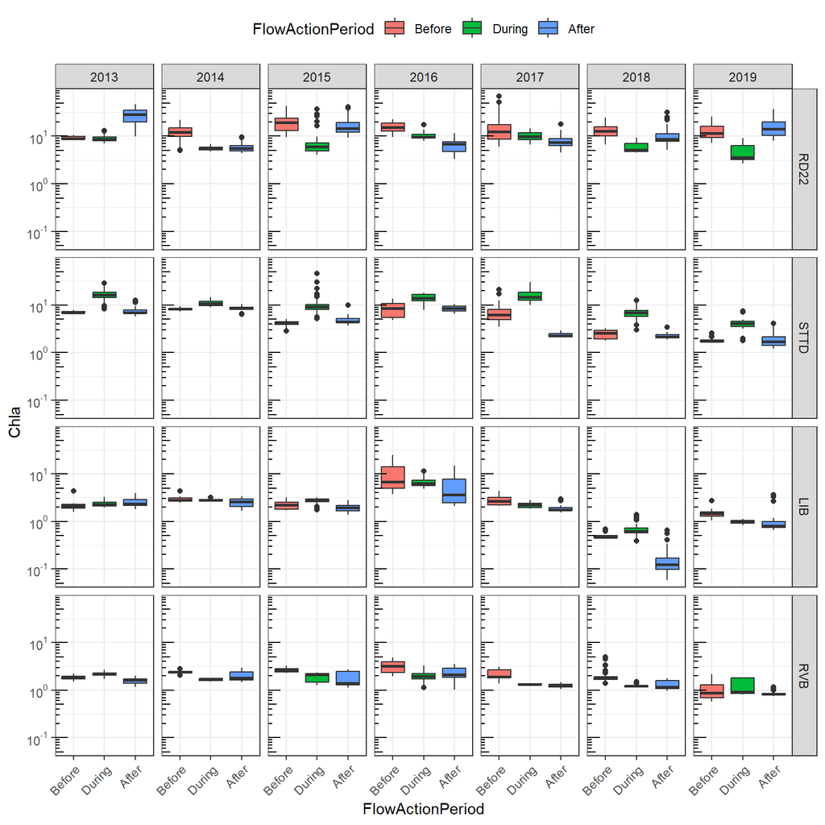

```r
df_chla_wt_c %>%
  ggplot(aes(x = FlowActionPeriod, y = Chla, fill = FlowActionPeriod)) +
  geom_boxplot() +
  facet_grid(cols = vars(Year), rows = vars(StationCode)) +
  scale_y_log10(labels = trans_format("log10", math_format(10^.x))) +
  annotation_logticks(sides = "l") +
  theme_bw() +
  theme(
    axis.text.x = element_text(angle = 45, hjust = 1, vjust = 1),
    legend.position = "top"
  )
```

# Models

## Model 1: GAM 3-way interactions with s(DOY)

### Initial Model

We’ll try running a GAM using a three-way interaction between Year, Flow Action Period, and Station, and a smooth term for day of year to account for seasonality (restricting the k-value to 5 to reduce overfitting). First we’ll run the GAM without accounting for serial autocorrelation.

```r
m_gam_cat3 <- gam(
  Chla_log ~ Year_fct * FlowActionPeriod * StationCode + s(DOY, k = 5),
  data = df_chla_wt_c,
  method = "REML"
)
```

Lets look at the model summary and diagnostics:

```r
summary(m_gam_cat3)
```

```
##
## Family: gaussian
## Link function: identity
##
## Formula:
## Chla_log ~ Year_fct * FlowActionPeriod * StationCode + s(DOY,
##     k = 5)
##
## Parametric coefficients:
##                                                     Estimate Std. Error t value
## (Intercept)                                          9.08117    0.11195  81.120
## Year_fct2014                                         0.19256    0.11869   1.622
## Year_fct2015                                         0.63992    0.12388   5.166
## Year_fct2016                                         0.30110    0.13277   2.268
## Year_fct2017                                         0.34181    0.11904   2.871
## Year_fct2018                                         0.25789    0.11910   2.165
## Year_fct2019                                         0.22433    0.11923   1.881
## FlowActionPeriodDuring                               0.10196    0.12080   0.844
## FlowActionPeriodAfter                                1.15670    0.12833   9.013
## StationCodeSTTD                                     -0.25842    0.15631  -1.653
## StationCodeLIB                                      -1.57515    0.12106 -13.011
## StationCodeRVB                                      -1.69525    0.11955 -14.180
## Year_fct2014:FlowActionPeriodDuring                 -0.65640    0.14774  -4.443
## Year_fct2015:FlowActionPeriodDuring                 -0.89633    0.13934  -6.433
## Year_fct2016:FlowActionPeriodDuring                 -0.40149    0.15420  -2.604
## Year_fct2017:FlowActionPeriodDuring                 -0.26619    0.14252  -1.868
## Year_fct2018:FlowActionPeriodDuring                 -0.69788    0.13815  -5.052
## Year_fct2019:FlowActionPeriodDuring                 -0.98774    0.13946  -7.083
## Year_fct2014:FlowActionPeriodAfter                  -1.67549    0.13620 -12.301
## Year_fct2015:FlowActionPeriodAfter                  -1.08617    0.14172  -7.664
## Year_fct2016:FlowActionPeriodAfter                  -1.79581    0.15340 -11.707
## Year_fct2017:FlowActionPeriodAfter                  -1.54569    0.13661 -11.315
## Year_fct2018:FlowActionPeriodAfter                  -1.23303    0.13656  -9.029
## Year_fct2019:FlowActionPeriodAfter                  -0.72868    0.13671  -5.330
## Year_fct2014:StationCodeSTTD                        -0.05655    0.16778  -0.337
## Year_fct2015:StationCodeSTTD                        -1.23388    0.17581  -7.018
## Year_fct2016:StationCodeSTTD                        -0.39579    0.18049  -2.193
## Year_fct2017:StationCodeSTTD                        -0.50185    0.16778  -2.991
## Year_fct2018:StationCodeSTTD                        -1.39676    0.16880  -8.275
## Year_fct2019:StationCodeSTTD                        -1.62927    0.17055  -9.553
```

[output cut: 135 more lines]

```
## Year_fct2016:FlowActionPeriodAfter:StationCodeRVB    < 2e-16 ***
## Year_fct2017:FlowActionPeriodAfter:StationCodeRVB   1.25e-13 ***
## Year_fct2018:FlowActionPeriodAfter:StationCodeRVB   1.64e-09 ***
## Year_fct2019:FlowActionPeriodAfter:StationCodeRVB   1.48e-06 ***
## ---
## Signif. codes:  0 '***' 0.001 '**' 0.01 '*' 0.05 '.' 0.1 ' ' 1
##
## Approximate significance of smooth terms:
##          edf Ref.df    F p-value
## s(DOY) 3.674  3.947 21.1  <2e-16 ***
## ---
## Signif. codes:  0 '***' 0.001 '**' 0.01 '*' 0.05 '.' 0.1 ' ' 1
##
## R-sq.(adj) =  0.917   Deviance explained = 91.9%
## -REML = 690.81  Scale est. = 0.085513  n = 2932
```

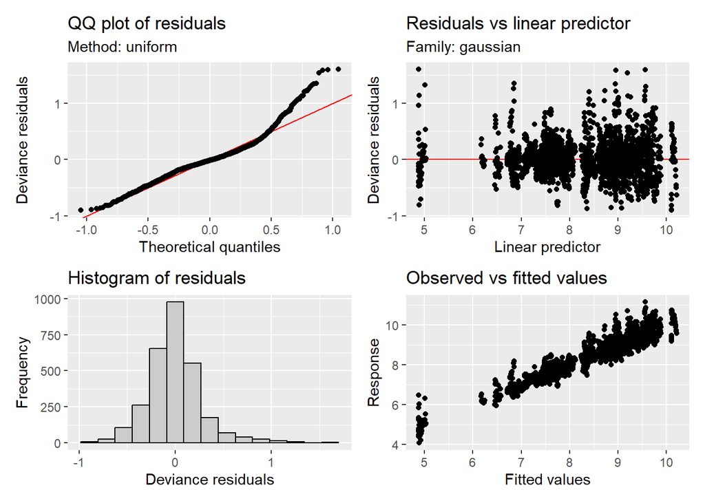

```r
appraise(m_gam_cat3)
```

```r
k.check(m_gam_cat3)
```

```
##        k'      edf  k-index p-value
## s(DOY)  4 3.674445 0.969169   0.055
```

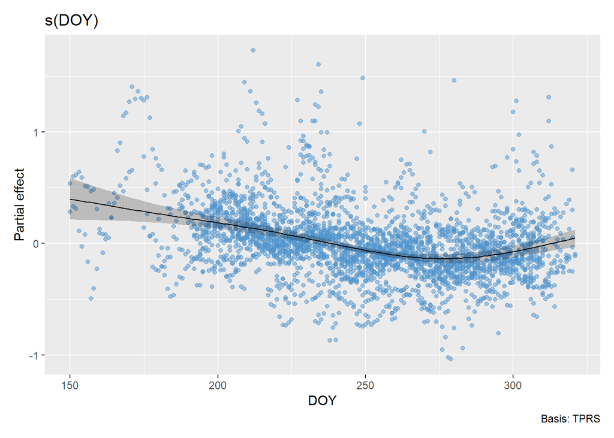

```r
draw(m_gam_cat3, select = 1, residuals = TRUE, rug = FALSE)
```

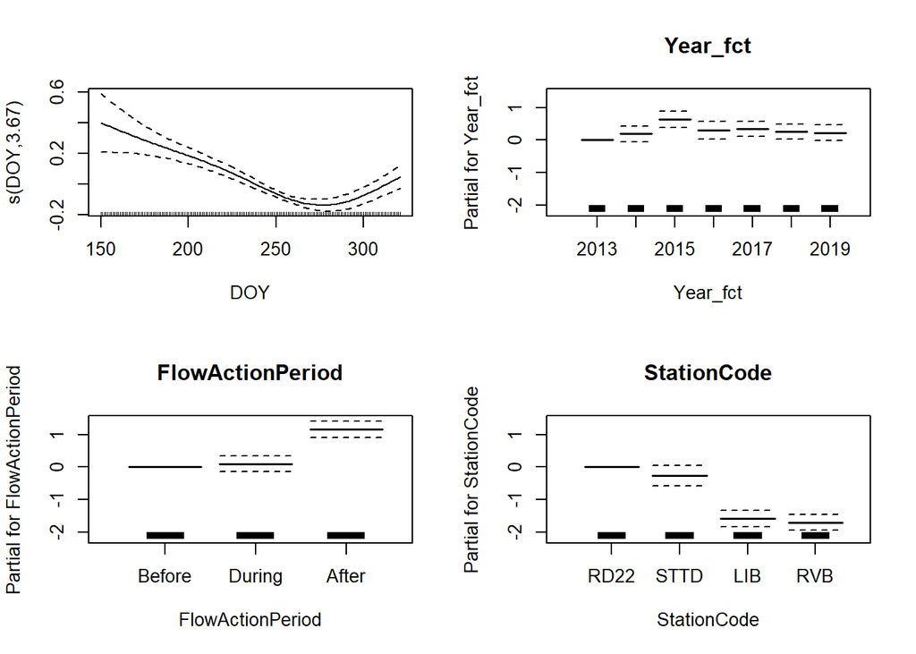

```r
plot(m_gam_cat3, pages = 1, all.terms = TRUE)
```

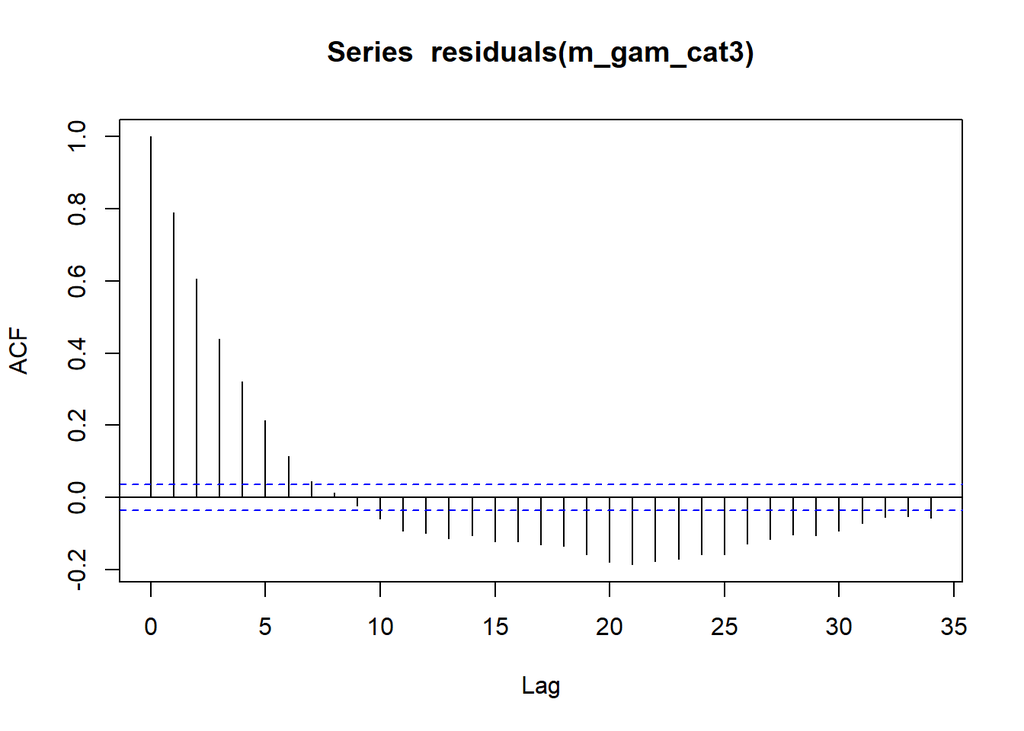

```r
acf(residuals(m_gam_cat3))
```

```r
Box.test(residuals(m_gam_cat3), lag = 20, type = 'Ljung-Box')
```

```
##
##  Box-Ljung test
##
## data:  residuals(m_gam_cat3)
## X-squared = 4457.9, df = 20, p-value < 2.2e-16
```

### Model with AR() correlation structure

Now, we’ll try to deal with the residual autocorrelation. We’ll run AR(1), AR(2), and AR(3) models and compare them using AIC.

```r
# Define model formula as an object
f_gam_cat3 <- as.formula("Chla_log ~ Year_fct * FlowActionPeriod * StationCode + s(DOY, k = 5)")

# Fit original model with k = 5 and three successive AR(p) models
m_gamm_cat3 <- gamm(
  f_gam_cat3,
  data = df_chla_wt_c,
  method = "REML"
)

m_gamm_cat3_ar1 <- gamm(
  f_gam_cat3,
  data = df_chla_wt_c,
  correlation = corARMA(form = ~ 1|Year_fct/StationCode, p = 1), # grouped by Year_fct and StationCode
  method = "REML"
)

m_gamm_cat3_ar2 <- gamm(
  f_gam_cat3,
  data = df_chla_wt_c,
  correlation = corARMA(form = ~ 1|Year_fct/StationCode, p = 2), # grouped by Year_fct and StationCode
  method = "REML"
)

m_gamm_cat3_ar3 <- gamm(
  f_gam_cat3,
  data = df_chla_wt_c,
  correlation = corARMA(form = ~ 1|Year_fct/StationCode, p = 3), # grouped by Year_fct and StationCode
  method = "REML"
)

# Compare models
anova(
  m_gamm_cat3$lme,
  m_gamm_cat3_ar1$lme,
  m_gamm_cat3_ar2$lme,
  m_gamm_cat3_ar3$lme
)
```

```
##                     Model df       AIC       BIC    logLik   Test  L.Ratio
## m_gamm_cat3$lme         1 87  1555.622  2073.622 -690.8109
## m_gamm_cat3_ar1$lme     2 88 -1932.180 -1408.226 1054.0899 1 vs 2 3489.802
## m_gamm_cat3_ar2$lme     3 89 -1930.971 -1401.063 1054.4856 2 vs 3    0.791
## m_gamm_cat3_ar3$lme     4 90 -1930.016 -1394.154 1055.0080 3 vs 4    1.045
##                     p-value
## m_gamm_cat3$lme
## m_gamm_cat3_ar1$lme  <.0001
## m_gamm_cat3_ar2$lme  0.3737
## m_gamm_cat3_ar3$lme  0.3067
```

It looks like the AR(1) model has the best fit according to the AIC values and backed up by the BIC values. Let’s take a closer look at that one.

### AR(1) Model

```r
# Pull out the residuals and the GAM model
resid_cat3_ar1 <- residuals(m_gamm_cat3_ar1$lme, type = "normalized")
m_gamm_cat3_ar1_gam <- m_gamm_cat3_ar1$gam

summary(m_gamm_cat3_ar1_gam)
```

```
##
## Family: gaussian
## Link function: identity
##
## Formula:
## Chla_log ~ Year_fct * FlowActionPeriod * StationCode + s(DOY,
##     k = 5)
##
## Parametric coefficients:
##                                                      Estimate Std. Error
## (Intercept)                                          9.463591   0.275846
## Year_fct2014                                        -0.305994   0.362737
## Year_fct2015                                        -0.039067   0.366802
## Year_fct2016                                        -0.583469   0.386983
## Year_fct2017                                        -0.389788   0.360791
## Year_fct2018                                        -0.083020   0.357441
## Year_fct2019                                        -0.273120   0.358662
## FlowActionPeriodDuring                               0.011851   0.165058
## FlowActionPeriodAfter                                0.116296   0.226462
## StationCodeSTTD                                     -0.262267   0.389697
## StationCodeLIB                                      -1.922016   0.359134
## StationCodeRVB                                      -1.972146   0.353906
## Year_fct2014:FlowActionPeriodDuring                 -0.100874   0.229879
## Year_fct2015:FlowActionPeriodDuring                 -0.185263   0.230420
## Year_fct2016:FlowActionPeriodDuring                  0.089598   0.231706
## Year_fct2017:FlowActionPeriodDuring                  0.001276   0.229562
## Year_fct2018:FlowActionPeriodDuring                 -0.318753   0.229152
## Year_fct2019:FlowActionPeriodDuring                  0.081118   0.229281
## Year_fct2014:FlowActionPeriodAfter                  -0.308063   0.310774
## Year_fct2015:FlowActionPeriodAfter                   0.057162   0.314450
## Year_fct2016:FlowActionPeriodAfter                  -0.055906   0.315211
## Year_fct2017:FlowActionPeriodAfter                   0.241987   0.310816
## Year_fct2018:FlowActionPeriodAfter                  -0.513149   0.310892
## Year_fct2019:FlowActionPeriodAfter                   0.232759   0.310865
## Year_fct2014:StationCodeSTTD                         0.121376   0.516288
## Year_fct2015:StationCodeSTTD                        -0.505324   0.519139
## Year_fct2016:StationCodeSTTD                         0.473585   0.541212
## Year_fct2017:StationCodeSTTD                         0.069676   0.529637
## Year_fct2018:StationCodeSTTD                        -1.169014   0.513617
## Year_fct2019:StationCodeSTTD                        -1.226391   0.514099
```

[output cut: 135 more lines]

```
## Year_fct2016:FlowActionPeriodAfter:StationCodeRVB    -0.210 0.833547
## Year_fct2017:FlowActionPeriodAfter:StationCodeRVB    -0.992 0.321107
## Year_fct2018:FlowActionPeriodAfter:StationCodeRVB     0.831 0.405853
## Year_fct2019:FlowActionPeriodAfter:StationCodeRVB    -0.576 0.564525
## ---
## Signif. codes:  0 '***' 0.001 '**' 0.01 '*' 0.05 '.' 0.1 ' ' 1
##
## Approximate significance of smooth terms:
##        edf Ref.df     F p-value
## s(DOY)   1      1 6.113  0.0135 *
## ---
## Signif. codes:  0 '***' 0.001 '**' 0.01 '*' 0.05 '.' 0.1 ' ' 1
##
## R-sq.(adj) =  0.844
##   Scale est. = 0.2084    n = 2932
```

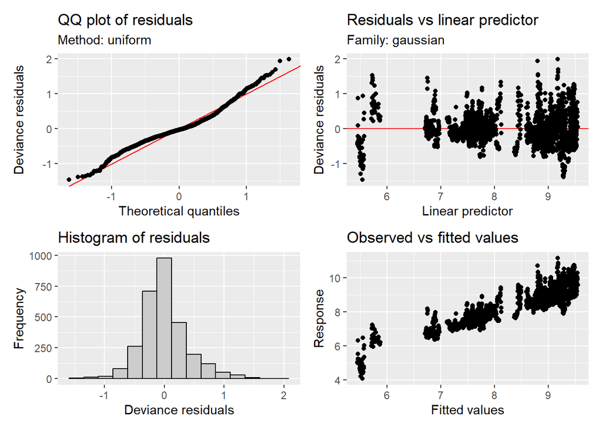

```r
appraise(m_gamm_cat3_ar1_gam)
```

```r
k.check(m_gamm_cat3_ar1_gam)
```

```
##        k'      edf   k-index p-value
## s(DOY)  4 1.000003 0.8948027       0
```

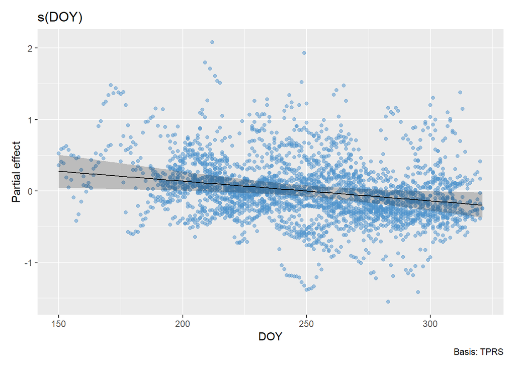

```r
draw(m_gamm_cat3_ar1_gam, select = 1, residuals = TRUE, rug = FALSE)
```

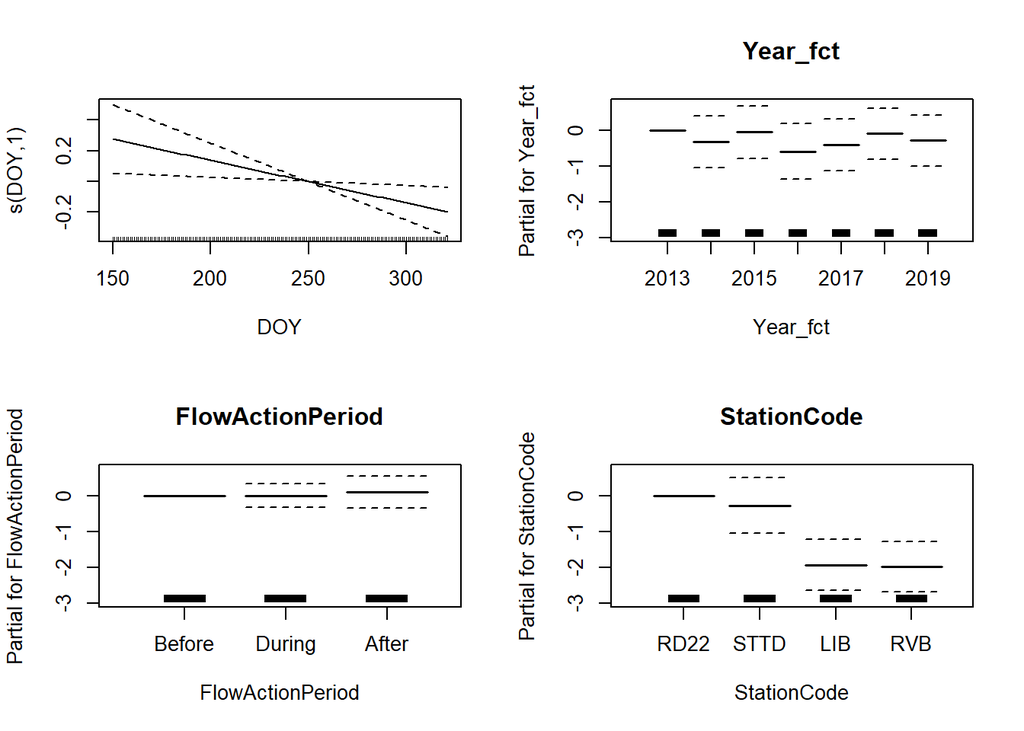

```r
plot(m_gamm_cat3_ar1_gam, pages = 1, all.terms = TRUE)
```

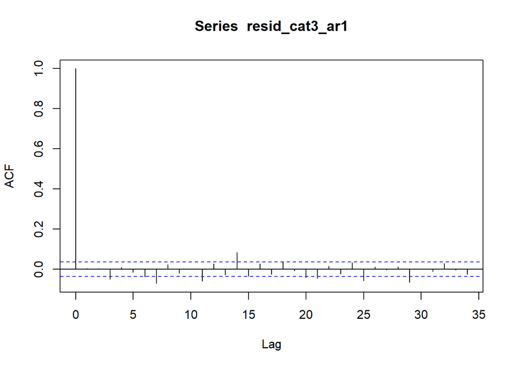

```r
acf(resid_cat3_ar1)
```

```r
Box.test(resid_cat3_ar1, lag = 20, type = 'Ljung-Box')
```

```
##
##  Box-Ljung test
##
## data:  resid_cat3_ar1
## X-squared = 81.422, df = 20, p-value = 2.249e-09
```

The AR(1) model has much less residual autocorrelation, and the diagnostics plots look pretty good. We’ll take a look at the ANOVA table to see if we need all the interaction terms included in the model.

```r
# the anova.gam function is similar to a type 3 ANOVA
anova(m_gamm_cat3_ar1_gam)
```

```
##
## Family: gaussian
## Link function: identity
##
## Formula:
## Chla_log ~ Year_fct * FlowActionPeriod * StationCode + s(DOY,
##     k = 5)
##
## Parametric Terms:
##                                       df      F  p-value
## Year_fct                               6  0.674    0.671
## FlowActionPeriod                       2  0.214    0.808
## StationCode                            3 17.439 3.22e-11
## Year_fct:FlowActionPeriod             12  1.275    0.226
## Year_fct:StationCode                  18  3.643 3.10e-07
## FlowActionPeriod:StationCode           6  0.788    0.579
## Year_fct:FlowActionPeriod:StationCode 36  3.809 2.52e-13
##
## Approximate significance of smooth terms:
##        edf Ref.df     F p-value
## s(DOY)   1      1 6.113  0.0135
```

The 3-way interaction term is significant in this model, so we’ll use this one for the model selection process.

```r
rm(m_gam_cat3, m_gamm_cat3, m_gamm_cat3_ar2, m_gamm_cat3_ar3)
```

## Model 2: LM 3-way interactions with water temperature

### Initial Model

We’ll try running a linear model using a three-way interaction between Year, Flow Action Period, and Station, and a covariate of water temperature to account for seasonality and its effect of primary production. First we’ll run the linear model without accounting for serial autocorrelation.

```r
m_lm_cat3_wt <- df_chla_wt_lag %>%
  drop_na(Chla_log, WaterTemp) %>%
  lm(Chla_log ~ Year_fct * FlowActionPeriod * StationCode + WaterTemp, data = .)
```

Lets look at the model summary and diagnostics:

```r
summary(m_lm_cat3_wt)
```

```
##
## Call:
## lm(formula = Chla_log ~ Year_fct * FlowActionPeriod * StationCode +
##     WaterTemp, data = .)
##
## Residuals:
##      Min       1Q   Median       3Q      Max
## -0.94130 -0.15240 -0.01843  0.12832  1.67114
##
## Coefficients:
##                                                      Estimate Std. Error
## (Intercept)                                          9.091520   0.146902
## Year_fct2014                                         0.198374   0.120464
## Year_fct2015                                         0.697112   0.125473
## Year_fct2016                                         0.499141   0.129685
## Year_fct2017                                         0.399696   0.120555
## Year_fct2018                                         0.322851   0.120469
## Year_fct2019                                         0.296743   0.120521
## FlowActionPeriodDuring                              -0.012914   0.121685
## FlowActionPeriodAfter                                1.023870   0.127559
## StationCodeSTTD                                     -0.258571   0.158710
## StationCodeLIB                                      -1.498069   0.122869
## StationCodeRVB                                      -1.599870   0.120735
## WaterTemp                                            0.001499   0.003927
## Year_fct2014:FlowActionPeriodDuring                 -0.690117   0.150044
## Year_fct2015:FlowActionPeriodDuring                 -0.951150   0.141255
## Year_fct2016:FlowActionPeriodDuring                 -0.368134   0.153919
## Year_fct2017:FlowActionPeriodDuring                 -0.320170   0.144456
## Year_fct2018:FlowActionPeriodDuring                 -0.767423   0.139823
## Year_fct2019:FlowActionPeriodDuring                 -1.053011   0.141021
## Year_fct2014:FlowActionPeriodAfter                  -1.683995   0.138584
## Year_fct2015:FlowActionPeriodAfter                  -1.134384   0.143849
## Year_fct2016:FlowActionPeriodAfter                  -1.898621   0.147625
## Year_fct2017:FlowActionPeriodAfter                  -1.616375   0.138232
## Year_fct2018:FlowActionPeriodAfter                  -1.290452   0.138359
## Year_fct2019:FlowActionPeriodAfter                  -0.806678   0.138200
## Year_fct2014:StationCodeSTTD                        -0.055493   0.170381
## Year_fct2015:StationCodeSTTD                        -1.239396   0.178545
## Year_fct2016:StationCodeSTTD                        -0.393709   0.183343
## Year_fct2017:StationCodeSTTD                        -0.500097   0.170420
```

[output cut: 133 more lines]

```
## Year_fct2017:FlowActionPeriodDuring:StationCodeRVB   -1.608 0.107844
## Year_fct2018:FlowActionPeriodDuring:StationCodeRVB    0.847 0.397037
## Year_fct2019:FlowActionPeriodDuring:StationCodeRVB    6.272 4.10e-10 ***
## Year_fct2014:FlowActionPeriodAfter:StationCodeRVB    10.131  < 2e-16 ***
## Year_fct2015:FlowActionPeriodAfter:StationCodeRVB     5.244 1.68e-07 ***
## Year_fct2016:FlowActionPeriodAfter:StationCodeRVB     9.881  < 2e-16 ***
## Year_fct2017:FlowActionPeriodAfter:StationCodeRVB     7.750 1.27e-14 ***
## Year_fct2018:FlowActionPeriodAfter:StationCodeRVB     6.365 2.27e-10 ***
## Year_fct2019:FlowActionPeriodAfter:StationCodeRVB     5.152 2.76e-07 ***
## ---
## Signif. codes:  0 '***' 0.001 '**' 0.01 '*' 0.05 '.' 0.1 ' ' 1
##
## Residual standard error: 0.2969 on 2843 degrees of freedom
## Multiple R-squared:  0.9168, Adjusted R-squared:  0.9143
## F-statistic: 372.8 on 84 and 2843 DF,  p-value: < 2.2e-16
```

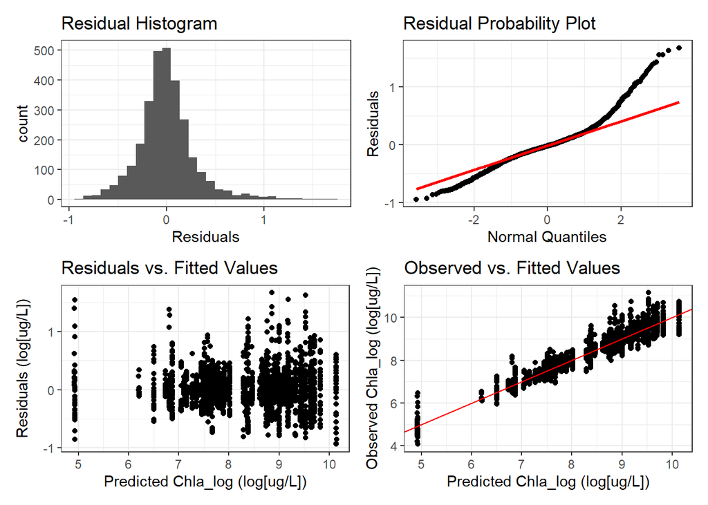

```r
df_chla_wt_lag %>%
  drop_na(Chla_log, WaterTemp) %>%
  plot_lm_diag(
    Chla_log,
    "ug/L",
    m_lm_cat3_wt,
    trans = "log"
  )
```

```r
shapiro.test(m_lm_cat3_wt$residuals)
```

```
##
##  Shapiro-Wilk normality test
##
## data:  m_lm_cat3_wt$residuals
## W = 0.94155, p-value < 2.2e-16
```

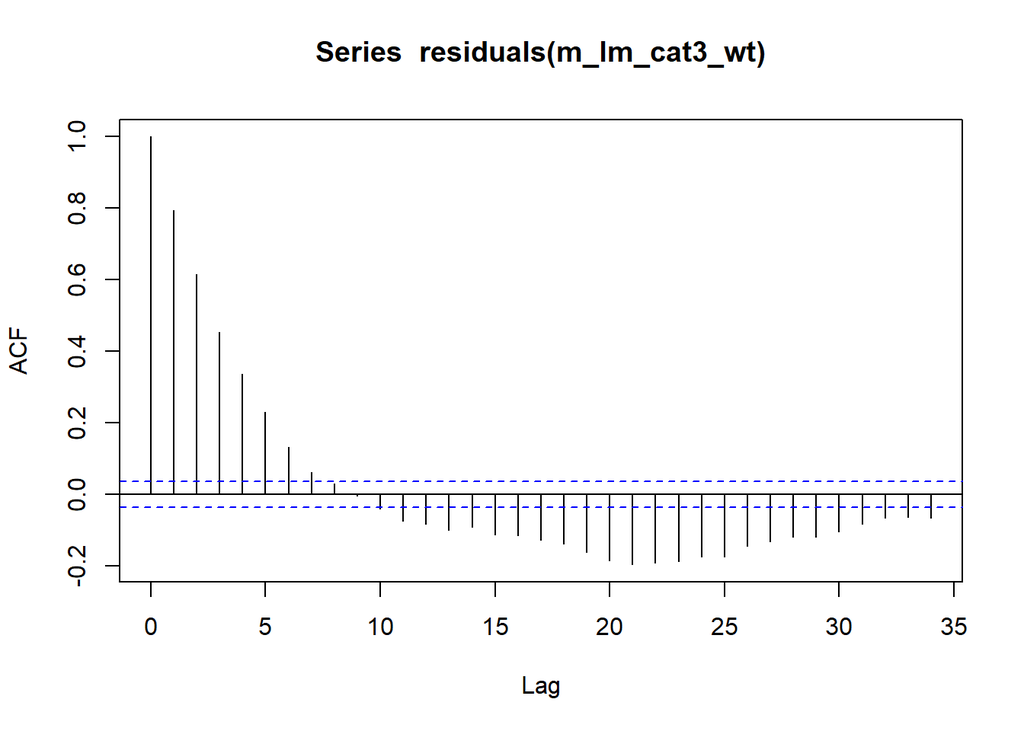

```r
acf(residuals(m_lm_cat3_wt))
```

```r
Box.test(residuals(m_lm_cat3_wt), lag = 20, type = 'Ljung-Box')
```

```
##
##  Box-Ljung test
##
## data:  residuals(m_lm_cat3_wt)
## X-squared = 4569.2, df = 20, p-value < 2.2e-16
```

Hmmm, the residuals deviate from a normal distribution according to visual inspection and the Shapiro-Wilk normality test. Also, the residuals are autocorrelated.

### Model with lag terms

Now, we’ll try to deal with the residual autocorrelation and the non-normal residuals. We’ll run a series of linear models adding 1, 2, and 3 lag terms and compare how well they correct for autocorrelation.

#### Lag 1

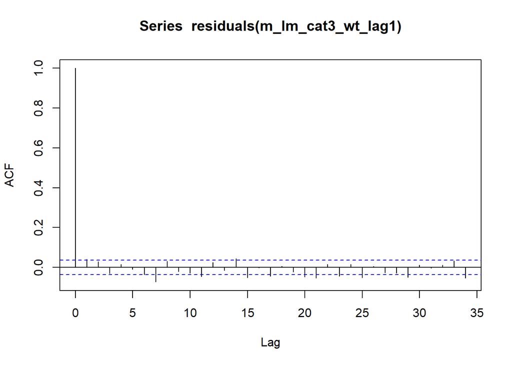

```r
m_lm_cat3_wt_lag1 <- df_chla_wt_lag %>%
  drop_na(Chla_log, WaterTemp, lag1) %>%
  lm(Chla_log ~ Year_fct * FlowActionPeriod * StationCode + WaterTemp + lag1, data = .)

acf(residuals(m_lm_cat3_wt_lag1))
```

```r
Box.test(residuals(m_lm_cat3_wt_lag1), lag = 20, type = 'Ljung-Box')
```

```
##
##  Box-Ljung test
##
## data:  residuals(m_lm_cat3_wt_lag1)
## X-squared = 72.103, df = 20, p-value = 8.23e-08
```

#### Lag 2

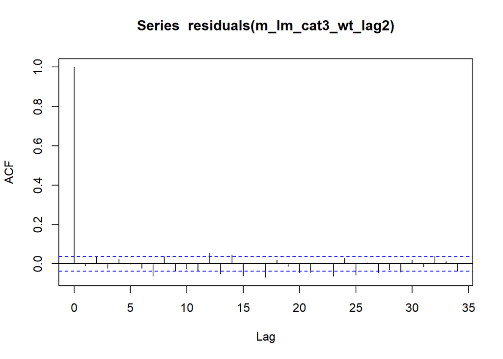

```r
m_lm_cat3_wt_lag2 <- df_chla_wt_lag %>%
  drop_na(Chla_log, WaterTemp, lag1, lag2) %>%
  lm(Chla_log ~ Year_fct * FlowActionPeriod * StationCode + WaterTemp + lag1 + lag2, data = .)

acf(residuals(m_lm_cat3_wt_lag2))
```

```r
Box.test(residuals(m_lm_cat3_wt_lag2), lag = 20, type = 'Ljung-Box')
```

```
##
##  Box-Ljung test
##
## data:  residuals(m_lm_cat3_wt_lag2)
## X-squared = 86.229, df = 20, p-value = 3.358e-10
```

#### Lag 3

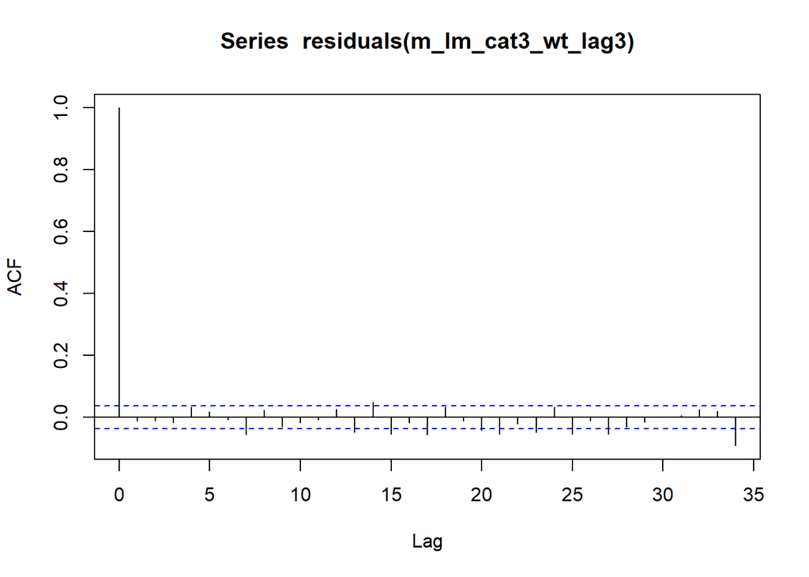

```r
m_lm_cat3_wt_lag3 <- df_chla_wt_lag %>%
  drop_na(Chla_log, WaterTemp, lag1, lag2, lag3) %>%
  lm(Chla_log ~ Year_fct * FlowActionPeriod * StationCode + WaterTemp + lag1 + lag2 + lag3, data = .)

acf(residuals(m_lm_cat3_wt_lag3))
```

```r
Box.test(residuals(m_lm_cat3_wt_lag3), lag = 20, type = 'Ljung-Box')
```

```
##
##  Box-Ljung test
##
## data:  residuals(m_lm_cat3_wt_lag3)
## X-squared = 61.572, df = 20, p-value = 4.056e-06
```

The model with 3 lag terms looks to have slightly better ACF and Box-Ljung test results than the model with 1 lag term. Let’s compare the 3 models using AIC and BIC to see which model those prefer.

#### Compare models

```r
AIC(m_lm_cat3_wt_lag1, m_lm_cat3_wt_lag2, m_lm_cat3_wt_lag3)
```

```
##                   df       AIC
## m_lm_cat3_wt_lag1 87 -2236.312
## m_lm_cat3_wt_lag2 88 -2197.327
## m_lm_cat3_wt_lag3 89 -2156.275
```

```r
BIC(m_lm_cat3_wt_lag1, m_lm_cat3_wt_lag2, m_lm_cat3_wt_lag3)
```

```
##                   df       BIC
## m_lm_cat3_wt_lag1 87 -1716.947
## m_lm_cat3_wt_lag2 88 -1673.096
## m_lm_cat3_wt_lag3 89 -1627.216
```

Both AIC and BIC prefer the model with 1 lag term. Let’s take a closer look at that one.

### Lag 1 model summary

```r
summary(m_lm_cat3_wt_lag1)
```

```
##
## Call:
## lm(formula = Chla_log ~ Year_fct * FlowActionPeriod * StationCode +
##     WaterTemp + lag1, data = .)
##
## Residuals:
##      Min       1Q   Median       3Q      Max
## -1.53589 -0.05777 -0.00825  0.04708  1.32305
##
## Coefficients:
##                                                       Estimate Std. Error
## (Intercept)                                          1.5433727  0.1254039
## Year_fct2014                                        -0.0182347  0.0704237
## Year_fct2015                                         0.1095640  0.0734276
## Year_fct2016                                         0.0559093  0.0756029
## Year_fct2017                                         0.0218486  0.0705498
## Year_fct2018                                         0.0187731  0.0704786
## Year_fct2019                                         0.0192824  0.0704744
## FlowActionPeriodDuring                              -0.0292730  0.0709500
## FlowActionPeriodAfter                                0.1510594  0.0747653
## StationCodeSTTD                                     -0.0524052  0.0935312
## StationCodeLIB                                      -0.2784185  0.0732843
## StationCodeRVB                                      -0.2988072  0.0723946
## WaterTemp                                            0.0006079  0.0021523
## lag1                                                 0.8325996  0.0101960
## Year_fct2014:FlowActionPeriodDuring                 -0.0558688  0.0859745
## Year_fct2015:FlowActionPeriodDuring                 -0.1786278  0.0817444
## Year_fct2016:FlowActionPeriodDuring                 -0.0493003  0.0880415
## Year_fct2017:FlowActionPeriodDuring                  0.0130437  0.0828428
## Year_fct2018:FlowActionPeriodDuring                 -0.0997253  0.0807290
## Year_fct2019:FlowActionPeriodDuring                 -0.1448880  0.0816976
## Year_fct2014:FlowActionPeriodAfter                  -0.2306039  0.0816099
## Year_fct2015:FlowActionPeriodAfter                  -0.1874236  0.0833563
## Year_fct2016:FlowActionPeriodAfter                  -0.3199999  0.0868441
## Year_fct2017:FlowActionPeriodAfter                  -0.2393589  0.0812347
## Year_fct2018:FlowActionPeriodAfter                  -0.1830236  0.0807085
## Year_fct2019:FlowActionPeriodAfter                  -0.0898510  0.0799562
## Year_fct2014:StationCodeSTTD                         0.0213002  0.0995410
## Year_fct2015:StationCodeSTTD                        -0.2171526  0.1047109
## Year_fct2016:StationCodeSTTD                        -0.0668027  0.1067229
```

[output cut: 135 more lines]

```
## Year_fct2017:FlowActionPeriodDuring:StationCodeRVB   -0.957 0.338825
## Year_fct2018:FlowActionPeriodDuring:StationCodeRVB   -0.090 0.928278
## Year_fct2019:FlowActionPeriodDuring:StationCodeRVB    1.219 0.222966
## Year_fct2014:FlowActionPeriodAfter:StationCodeRVB     2.462 0.013872 *
## Year_fct2015:FlowActionPeriodAfter:StationCodeRVB     1.707 0.087933 .
## Year_fct2016:FlowActionPeriodAfter:StationCodeRVB     2.911 0.003637 **
## Year_fct2017:FlowActionPeriodAfter:StationCodeRVB     2.115 0.034530 *
## Year_fct2018:FlowActionPeriodAfter:StationCodeRVB     1.592 0.111466
## Year_fct2019:FlowActionPeriodAfter:StationCodeRVB     0.921 0.357247
## ---
## Signif. codes:  0 '***' 0.001 '**' 0.01 '*' 0.05 '.' 0.1 ' ' 1
##
## Residual standard error: 0.1619 on 2806 degrees of freedom
## Multiple R-squared:  0.9753, Adjusted R-squared:  0.9746
## F-statistic:  1305 on 85 and 2806 DF,  p-value: < 2.2e-16
```

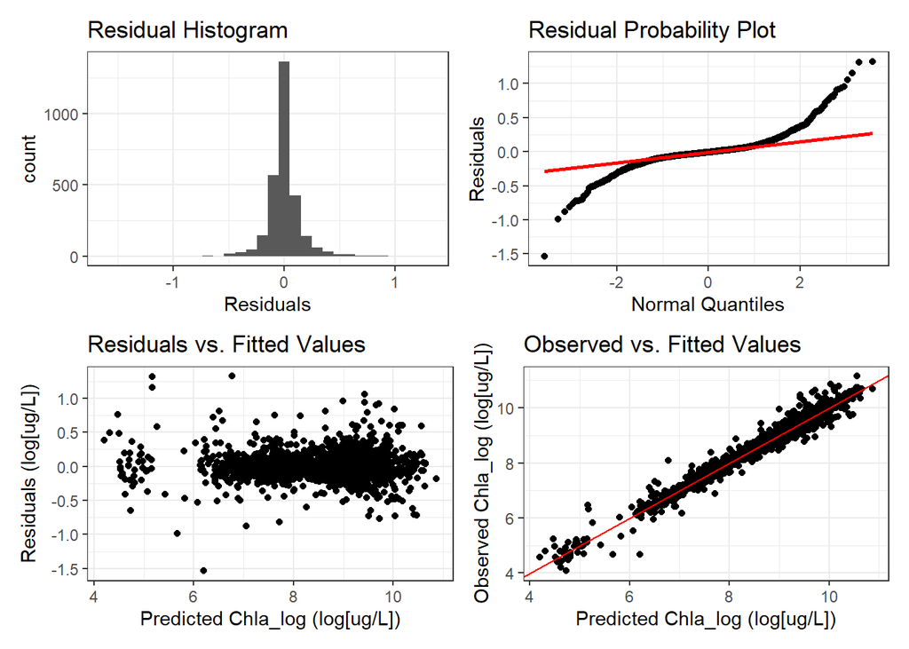

```r
df_chla_wt_lag %>%
  drop_na(Chla_log, WaterTemp, lag1) %>%
  plot_lm_diag(
    Chla_log,
    "ug/L",
    m_lm_cat3_wt_lag1,
    trans = "log"
  )
```

```r
shapiro.test(m_lm_cat3_wt_lag1$residuals)
```

```
##
##  Shapiro-Wilk normality test
##
## data:  m_lm_cat3_wt_lag1$residuals
## W = 0.82377, p-value < 2.2e-16
```

Hmmm, the residuals deviate from a normal distribution particularly at the both tails of the distribution. I’m not so sure about using this model. Let’s take a look at its ANOVA table using type 3 sum of squares.

```r
Anova(m_lm_cat3_wt_lag1, type = 3, contrasts = list(topic = contr.sum, sys = contr.sum))
```

```
## Anova Table (Type III tests)
##
## Response: Chla_log
##                                        Sum Sq   Df   F value    Pr(>F)
## (Intercept)                             3.972    1  151.4675 < 2.2e-16 ***
## Year_fct                                0.298    6    1.8941   0.07815 .
## FlowActionPeriod                        0.518    2    9.8844 5.276e-05 ***
## StationCode                             0.678    3    8.6139 1.087e-05 ***
## WaterTemp                               0.002    1    0.0798   0.77764
## lag1                                  174.861    1 6668.2887 < 2.2e-16 ***
## Year_fct:FlowActionPeriod               1.550   12    4.9252 4.070e-08 ***
## Year_fct:StationCode                    2.086   18    4.4201 1.458e-09 ***
## FlowActionPeriod:StationCode            0.981    6    6.2339 1.622e-06 ***
## Year_fct:FlowActionPeriod:StationCode   2.516   36    2.6656 3.306e-07 ***
## Residuals                              73.581 2806
## ---
## Signif. codes:  0 '***' 0.001 '**' 0.01 '*' 0.05 '.' 0.1 ' ' 1
```

All the interaction terms are significant, so we can use this model in our model selection process; however, I’m somewhat leery of using this model since the model residuals don’t look right and the water temperature term isn’t significant.

```r
rm(m_lm_cat3_wt, m_lm_cat3_wt_lag2, m_lm_cat3_wt_lag3)
```

## Model 3: LM 3-way interactions without seasonal term

### Initial Model

We’ll try running a linear model using a three-way interaction between Year, Flow Action Period, and Station without including a term to account for seasonality. First we’ll run the linear model without accounting for serial autocorrelation.

```r
m_lm_cat3 <- df_chla_wt_lag %>%
  drop_na(Chla_log) %>%
  lm(Chla_log ~ Year_fct * FlowActionPeriod * StationCode, data = .)
```

Lets look at the model summary and diagnostics:

```r
summary(m_lm_cat3)
```

```
##
## Call:
## lm(formula = Chla_log ~ Year_fct * FlowActionPeriod * StationCode,
##     data = .)
##
## Residuals:
##      Min       1Q   Median       3Q      Max
## -0.94020 -0.15272 -0.01851  0.12896  1.67404
##
## Coefficients:
##                                                      Estimate Std. Error
## (Intercept)                                          9.127697   0.112233
## Year_fct2014                                         0.198038   0.120470
## Year_fct2015                                         0.697361   0.125480
## Year_fct2016                                         0.501078   0.129596
## Year_fct2017                                         0.401506   0.120470
## Year_fct2018                                         0.322344   0.120470
## Year_fct2019                                         0.298192   0.120470
## FlowActionPeriodDuring                              -0.016983   0.121226
## FlowActionPeriodAfter                                1.011768   0.123565
## StationCodeSTTD                                     -0.258422   0.158722
## StationCodeLIB                                      -1.502245   0.122390
## StationCodeRVB                                      -1.602973   0.120470
## Year_fct2014:FlowActionPeriodDuring                 -0.688171   0.149969
## Year_fct2015:FlowActionPeriodDuring                 -0.949838   0.141224
## Year_fct2016:FlowActionPeriodDuring                 -0.363312   0.153412
## Year_fct2017:FlowActionPeriodDuring                 -0.317224   0.144261
## Year_fct2018:FlowActionPeriodDuring                 -0.766901   0.139827
## Year_fct2019:FlowActionPeriodDuring                 -1.051709   0.140990
## Year_fct2014:FlowActionPeriodAfter                  -1.680057   0.138209
## Year_fct2015:FlowActionPeriodAfter                  -1.131101   0.143602
## Year_fct2016:FlowActionPeriodAfter                  -1.890869   0.146232
## Year_fct2017:FlowActionPeriodAfter                  -1.615221   0.138209
## Year_fct2018:FlowActionPeriodAfter                  -1.287915   0.138209
## Year_fct2019:FlowActionPeriodAfter                  -0.806499   0.138209
## Year_fct2014:StationCodeSTTD                        -0.056554   0.170371
## Year_fct2015:StationCodeSTTD                        -1.240850   0.178518
## Year_fct2016:StationCodeSTTD                        -0.395790   0.183276
## Year_fct2017:StationCodeSTTD                        -0.501852   0.170371
## Year_fct2018:StationCodeSTTD                        -1.412505   0.171377
```

[output cut: 131 more lines]

```
## Year_fct2017:FlowActionPeriodDuring:StationCodeRVB   -1.625 0.104321
## Year_fct2018:FlowActionPeriodDuring:StationCodeRVB    0.836 0.403371
## Year_fct2019:FlowActionPeriodDuring:StationCodeRVB    6.263 4.36e-10 ***
## Year_fct2014:FlowActionPeriodAfter:StationCodeRVB    10.131  < 2e-16 ***
## Year_fct2015:FlowActionPeriodAfter:StationCodeRVB     5.238 1.74e-07 ***
## Year_fct2016:FlowActionPeriodAfter:StationCodeRVB     9.882  < 2e-16 ***
## Year_fct2017:FlowActionPeriodAfter:StationCodeRVB     7.746 1.31e-14 ***
## Year_fct2018:FlowActionPeriodAfter:StationCodeRVB     6.361 2.32e-10 ***
## Year_fct2019:FlowActionPeriodAfter:StationCodeRVB     5.148 2.82e-07 ***
## ---
## Signif. codes:  0 '***' 0.001 '**' 0.01 '*' 0.05 '.' 0.1 ' ' 1
##
## Residual standard error: 0.2969 on 2848 degrees of freedom
## Multiple R-squared:  0.9167, Adjusted R-squared:  0.9142
## F-statistic: 377.4 on 83 and 2848 DF,  p-value: < 2.2e-16
```

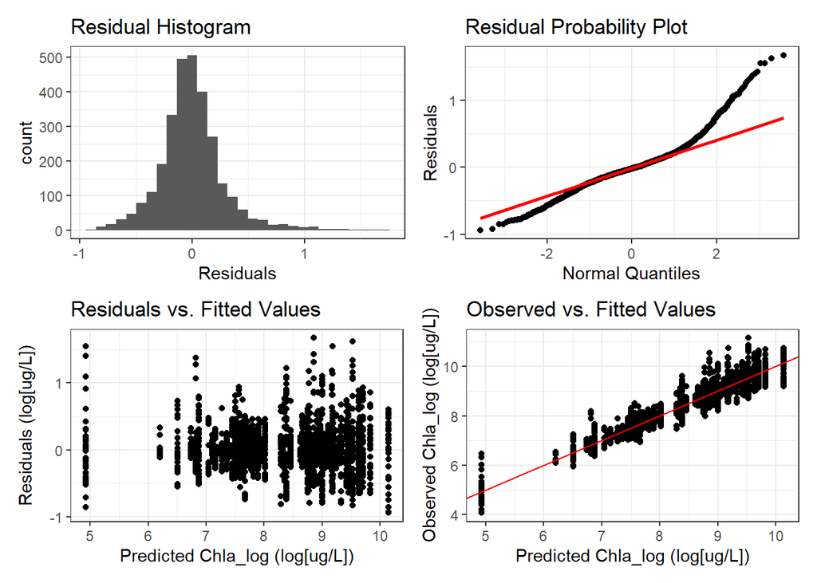

```r
df_chla_wt_lag %>%
  drop_na(Chla_log) %>%
  plot_lm_diag(
    Chla_log,
    "ug/L",
    m_lm_cat3,
    trans = "log"
  )
```

```r
shapiro.test(m_lm_cat3$residuals)
```

```
##
##  Shapiro-Wilk normality test
##
## data:  m_lm_cat3$residuals
## W = 0.94201, p-value < 2.2e-16
```

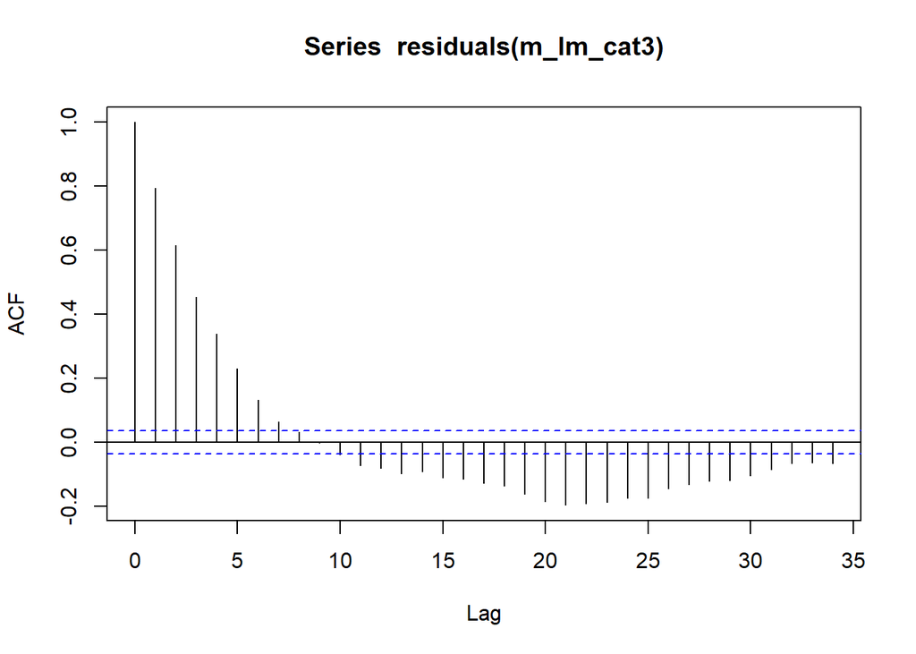

```r
acf(residuals(m_lm_cat3))
```

```r
Box.test(residuals(m_lm_cat3), lag = 20, type = 'Ljung-Box')
```

```
##
##  Box-Ljung test
##
## data:  residuals(m_lm_cat3)
## X-squared = 4580.6, df = 20, p-value < 2.2e-16
```

Hmmm, the residuals deviate from a normal distribution according to visual inspection and the Shapiro-Wilk normality test. Also, the residuals are autocorrelated.

### Model with lag terms

Now, we’ll try to deal with the residual autocorrelation and the non-normal residuals. We’ll run a series of linear models adding 1, 2, and 3 lag terms and compare how well they correct for autocorrelation.

#### Lag 1

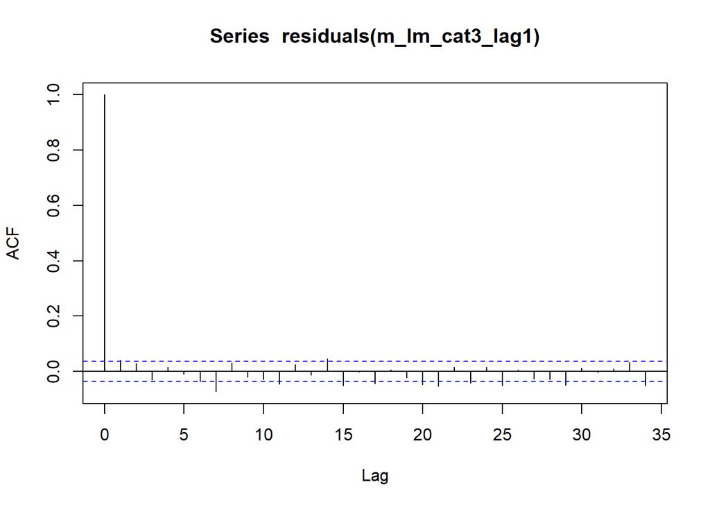

```r
m_lm_cat3_lag1 <- df_chla_wt_lag %>%
  drop_na(Chla_log, lag1) %>%
  lm(Chla_log ~ Year_fct * FlowActionPeriod * StationCode + lag1, data = .)

acf(residuals(m_lm_cat3_lag1))
```

```r
Box.test(residuals(m_lm_cat3_lag1), lag = 20, type = 'Ljung-Box')
```

```
##
##  Box-Ljung test
##
## data:  residuals(m_lm_cat3_lag1)
## X-squared = 72.215, df = 20, p-value = 7.889e-08
```

#### Lag 2

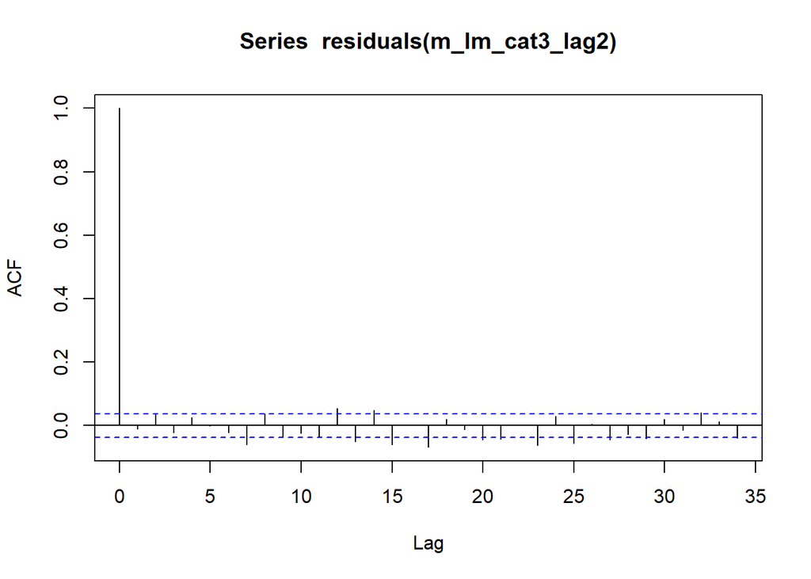

```r
m_lm_cat3_lag2 <- df_chla_wt_lag %>%
  drop_na(Chla_log, lag1, lag2) %>%
  lm(Chla_log ~ Year_fct * FlowActionPeriod * StationCode + lag1 + lag2, data = .)

acf(residuals(m_lm_cat3_lag2))
```

```r
Box.test(residuals(m_lm_cat3_lag2), lag = 20, type = 'Ljung-Box')
```

```
##
##  Box-Ljung test
##
## data:  residuals(m_lm_cat3_lag2)
## X-squared = 86.357, df = 20, p-value = 3.191e-10
```

#### Lag 3

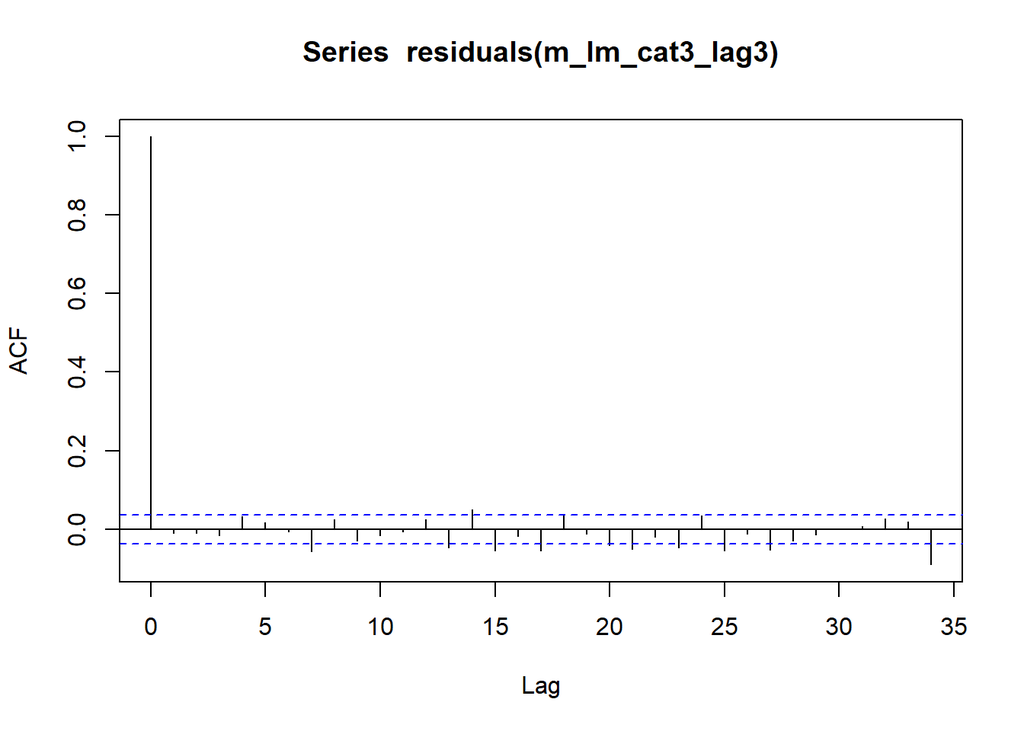

```r
m_lm_cat3_lag3 <- df_chla_wt_lag %>%
  drop_na(Chla_log, lag1, lag2, lag3) %>%
  lm(Chla_log ~ Year_fct * FlowActionPeriod * StationCode + lag1 + lag2 + lag3, data = .)

acf(residuals(m_lm_cat3_lag3))
```

```r
Box.test(residuals(m_lm_cat3_lag3), lag = 20, type = 'Ljung-Box')
```

```
##
##  Box-Ljung test
##
## data:  residuals(m_lm_cat3_lag3)
## X-squared = 61.887, df = 20, p-value = 3.622e-06
```

The model with 3 lag terms looks to have slightly better ACF and Box-Ljung test results than the model with 1 lag term. Let’s compare the 3 models using AIC and BIC to see which model those prefer.

#### Compare models

```r
AIC(m_lm_cat3_lag1, m_lm_cat3_lag2, m_lm_cat3_lag3)
```

```
##                df       AIC
## m_lm_cat3_lag1 86 -2244.328
## m_lm_cat3_lag2 87 -2205.247
## m_lm_cat3_lag3 88 -2163.924
```

```r
BIC(m_lm_cat3_lag1, m_lm_cat3_lag2, m_lm_cat3_lag3)
```

```
##                df       BIC
## m_lm_cat3_lag1 86 -1730.815
## m_lm_cat3_lag2 87 -1686.851
## m_lm_cat3_lag3 88 -1640.684
```

Both AIC and BIC prefer the model with 1 lag term. Let’s take a closer look at that one.

### Lag 1 model summary

```r
summary(m_lm_cat3_lag1)
```

```
##
## Call:
## lm(formula = Chla_log ~ Year_fct * FlowActionPeriod * StationCode +
##     lag1, data = .)
##
## Residuals:
##      Min       1Q   Median       3Q      Max
## -1.53572 -0.05749 -0.00790  0.04703  1.32211
##
## Coefficients:
##                                                      Estimate Std. Error
## (Intercept)                                          1.555707   0.113899
## Year_fct2014                                        -0.018563   0.070371
## Year_fct2015                                         0.109392   0.073378
## Year_fct2016                                         0.056486   0.075510
## Year_fct2017                                         0.022339   0.070470
## Year_fct2018                                         0.018340   0.070421
## Year_fct2019                                         0.019667   0.070408
## FlowActionPeriodDuring                              -0.031037   0.070627
## FlowActionPeriodAfter                                0.145762   0.072563
## StationCodeSTTD                                     -0.052358   0.093469
## StationCodeLIB                                      -0.279822   0.072957
## StationCodeRVB                                      -0.299776   0.072177
## lag1                                                 0.832869   0.010180
## Year_fct2014:FlowActionPeriodDuring                 -0.054753   0.085855
## Year_fct2015:FlowActionPeriodDuring                 -0.177763   0.081659
## Year_fct2016:FlowActionPeriodDuring                 -0.047178   0.087690
## Year_fct2017:FlowActionPeriodDuring                  0.014467   0.082655
## Year_fct2018:FlowActionPeriodDuring                 -0.099169   0.080665
## Year_fct2019:FlowActionPeriodDuring                 -0.143954   0.081610
## Year_fct2014:FlowActionPeriodAfter                  -0.228415   0.081320
## Year_fct2015:FlowActionPeriodAfter                  -0.185703   0.083147
## Year_fct2016:FlowActionPeriodAfter                  -0.316281   0.086029
## Year_fct2017:FlowActionPeriodAfter                  -0.238324   0.081149
## Year_fct2018:FlowActionPeriodAfter                  -0.181508   0.080546
## Year_fct2019:FlowActionPeriodAfter                  -0.089433   0.079899
## Year_fct2014:StationCodeSTTD                         0.020969   0.099467
## Year_fct2015:StationCodeSTTD                        -0.217358   0.104624
## Year_fct2016:StationCodeSTTD                        -0.067518   0.106612
## Year_fct2017:StationCodeSTTD                        -0.047307   0.099606
```

[output cut: 133 more lines]

```
## Year_fct2017:FlowActionPeriodDuring:StationCodeRVB   -0.970 0.332229
## Year_fct2018:FlowActionPeriodDuring:StationCodeRVB   -0.100 0.919970
## Year_fct2019:FlowActionPeriodDuring:StationCodeRVB    1.207 0.227614
## Year_fct2014:FlowActionPeriodAfter:StationCodeRVB     2.458 0.014041 *
## Year_fct2015:FlowActionPeriodAfter:StationCodeRVB     1.700 0.089190 .
## Year_fct2016:FlowActionPeriodAfter:StationCodeRVB     2.909 0.003660 **
## Year_fct2017:FlowActionPeriodAfter:StationCodeRVB     2.108 0.035108 *
## Year_fct2018:FlowActionPeriodAfter:StationCodeRVB     1.586 0.112766
## Year_fct2019:FlowActionPeriodAfter:StationCodeRVB     0.915 0.360457
## ---
## Signif. codes:  0 '***' 0.001 '**' 0.01 '*' 0.05 '.' 0.1 ' ' 1
##
## Residual standard error: 0.1618 on 2811 degrees of freedom
## Multiple R-squared:  0.9753, Adjusted R-squared:  0.9746
## F-statistic:  1323 on 84 and 2811 DF,  p-value: < 2.2e-16
```

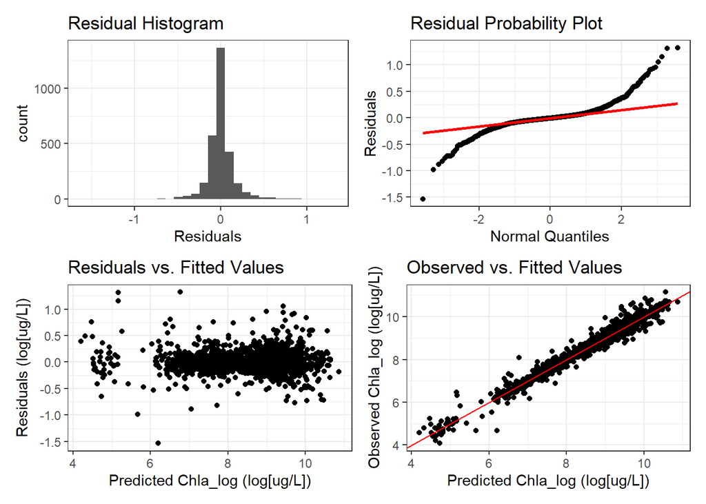

```r
df_chla_wt_lag %>%
  drop_na(Chla_log, lag1) %>%
  plot_lm_diag(
    Chla_log,
    "ug/L",
    m_lm_cat3_lag1,
    trans = "log"
  )
```

```r
shapiro.test(m_lm_cat3_lag1$residuals)
```

```
##
##  Shapiro-Wilk normality test
##
## data:  m_lm_cat3_lag1$residuals
## W = 0.82379, p-value < 2.2e-16
```

Hmmm, again the residuals deviate from a normal distribution particularly at the both tails of the distribution. I’m not so sure about using this model. Let’s take a look at its ANOVA table using type 3 sum of squares.

```r
Anova(m_lm_cat3_lag1, type = 3, contrasts = list(topic = contr.sum, sys = contr.sum))
```

```
## Anova Table (Type III tests)
##
## Response: Chla_log
##                                        Sum Sq   Df   F value    Pr(>F)
## (Intercept)                             4.886    1  186.5576 < 2.2e-16 ***
## Year_fct                                0.299    6    1.9058   0.07623 .
## FlowActionPeriod                        0.546    2   10.4251 3.084e-05 ***
## StationCode                             0.690    3    8.7860 8.495e-06 ***
## lag1                                  175.299    1 6693.8549 < 2.2e-16 ***
## Year_fct:FlowActionPeriod               1.547   12    4.9233 4.106e-08 ***
## Year_fct:StationCode                    2.081   18    4.4137 1.525e-09 ***
## FlowActionPeriod:StationCode            0.980    6    6.2376 1.606e-06 ***
## Year_fct:FlowActionPeriod:StationCode   2.519   36    2.6719 3.074e-07 ***
## Residuals                              73.614 2811
## ---
## Signif. codes:  0 '***' 0.001 '**' 0.01 '*' 0.05 '.' 0.1 ' ' 1
```

All the interaction terms are significant, so we can use this model in our model selection process; however, I’m somewhat leery of using this model since the model residuals don’t look right.

```r
rm(m_lm_cat3, m_lm_cat3_lag2, m_lm_cat3_lag3)
```

## Model 4: GAM 2-way interactions with s(DOY)

### Initial Model

We’ll try running a GAM using all two-way interactions between Year, Flow Action Period, and Station, and a smooth term for day of year to account for seasonality (restricting the k-value to 5 to reduce overfitting). First we’ll run the GAM without accounting for serial autocorrelation.

```r
m_gam_cat2 <- gam(
  Chla_log ~ (Year_fct + FlowActionPeriod + StationCode)^2 + s(DOY, k = 5),
  data = df_chla_wt_c,
  method = "REML"
)
```

Lets look at the model summary and diagnostics:

```r
summary(m_gam_cat2)
```

```
##
## Family: gaussian
## Link function: identity
##
## Formula:
## Chla_log ~ (Year_fct + FlowActionPeriod + StationCode)^2 + s(DOY,
##     k = 5)
##
## Parametric coefficients:
##                                        Estimate Std. Error t value Pr(>|t|)
## (Intercept)                             9.64975    0.06314 152.819  < 2e-16 ***
## Year_fct2014                           -0.50817    0.06713  -7.570 5.00e-14 ***
## Year_fct2015                            0.01230    0.06728   0.183 0.854968
## Year_fct2016                           -0.39765    0.08211  -4.843 1.35e-06 ***
## Year_fct2017                           -0.17198    0.06670  -2.579 0.009972 **
## Year_fct2018                           -0.24509    0.06655  -3.683 0.000235 ***
## Year_fct2019                           -0.29125    0.06660  -4.373 1.27e-05 ***
## FlowActionPeriodDuring                 -0.36091    0.06217  -5.806 7.11e-09 ***
## FlowActionPeriodAfter                   0.32490    0.07297   4.452 8.81e-06 ***
## StationCodeSTTD                        -1.10053    0.06546 -16.811  < 2e-16 ***
## StationCodeLIB                         -2.14605    0.05927 -36.207  < 2e-16 ***
## StationCodeRVB                         -2.29306    0.05826 -39.358  < 2e-16 ***
## Year_fct2014:FlowActionPeriodDuring    -0.41511    0.06845  -6.064 1.50e-09 ***
## Year_fct2015:FlowActionPeriodDuring    -0.23567    0.05960  -3.954 7.86e-05 ***
## Year_fct2016:FlowActionPeriodDuring    -0.36454    0.08077  -4.513 6.64e-06 ***
## Year_fct2017:FlowActionPeriodDuring    -0.27042    0.06710  -4.030 5.72e-05 ***
## Year_fct2018:FlowActionPeriodDuring    -0.12610    0.06249  -2.018 0.043693 *
## Year_fct2019:FlowActionPeriodDuring    -0.24824    0.06405  -3.876 0.000109 ***
## Year_fct2014:FlowActionPeriodAfter     -0.46589    0.05896  -7.902 3.86e-15 ***
## Year_fct2015:FlowActionPeriodAfter     -0.30129    0.05891  -5.115 3.35e-07 ***
## Year_fct2016:FlowActionPeriodAfter     -0.53779    0.08552  -6.288 3.69e-10 ***
## Year_fct2017:FlowActionPeriodAfter     -0.63694    0.06061 -10.508  < 2e-16 ***
## Year_fct2018:FlowActionPeriodAfter     -0.64681    0.06101 -10.602  < 2e-16 ***
## Year_fct2019:FlowActionPeriodAfter     -0.19776    0.05999  -3.297 0.000991 ***
## Year_fct2014:StationCodeSTTD            0.90359    0.07400  12.211  < 2e-16 ***
## Year_fct2015:StationCodeSTTD           -0.26654    0.06977  -3.821 0.000136 ***
## Year_fct2016:StationCodeSTTD            0.69399    0.07466   9.295  < 2e-16 ***
## Year_fct2017:StationCodeSTTD            0.22832    0.08222   2.777 0.005521 **
## Year_fct2018:StationCodeSTTD           -0.50639    0.07249  -6.986 3.50e-12 ***
## Year_fct2019:StationCodeSTTD           -0.90290    0.07074 -12.763  < 2e-16 ***
```

[output cut: 14 more lines]

```
## FlowActionPeriodDuring:StationCodeLIB   0.81415    0.04847  16.798  < 2e-16 ***
## FlowActionPeriodAfter:StationCodeLIB   -0.08208    0.04215  -1.947 0.051590 .
## FlowActionPeriodDuring:StationCodeRVB   0.55212    0.04650  11.874  < 2e-16 ***
## FlowActionPeriodAfter:StationCodeRVB   -0.04128    0.04056  -1.018 0.308841
## ---
## Signif. codes:  0 '***' 0.001 '**' 0.01 '*' 0.05 '.' 0.1 ' ' 1
##
## Approximate significance of smooth terms:
##          edf Ref.df     F p-value
## s(DOY) 3.527  3.892 15.38  <2e-16 ***
## ---
## Signif. codes:  0 '***' 0.001 '**' 0.01 '*' 0.05 '.' 0.1 ' ' 1
##
## R-sq.(adj) =  0.889   Deviance explained = 89.1%
## -REML = 1070.5  Scale est. = 0.11366   n = 2932
```

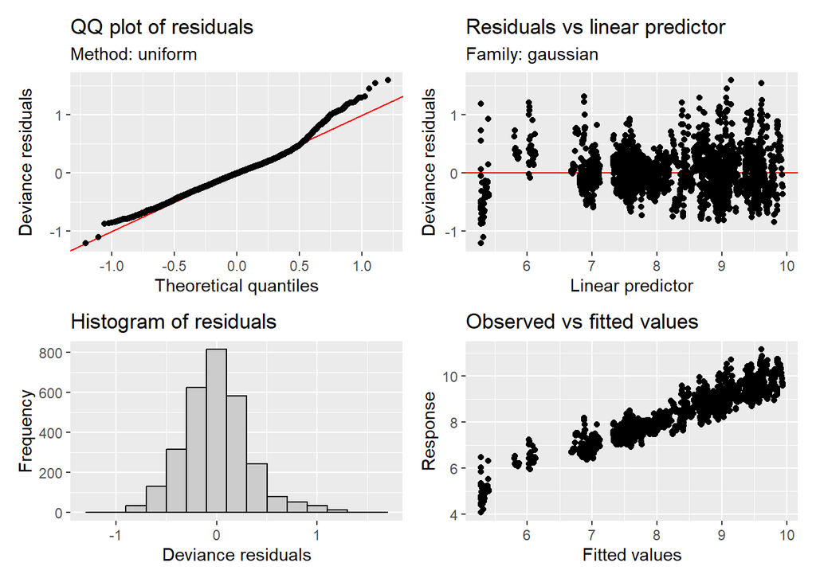

```r
appraise(m_gam_cat2)
```

```r
k.check(m_gam_cat2)
```

```
##        k'      edf  k-index p-value
## s(DOY)  4 3.526722 1.026702  0.9225
```

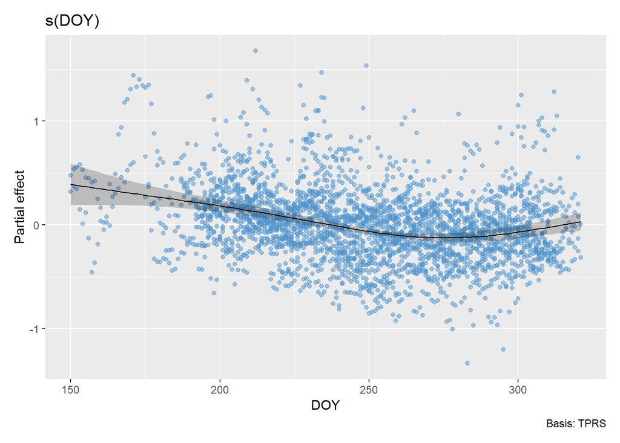

```r
draw(m_gam_cat2, select = 1, residuals = TRUE, rug = FALSE)
```

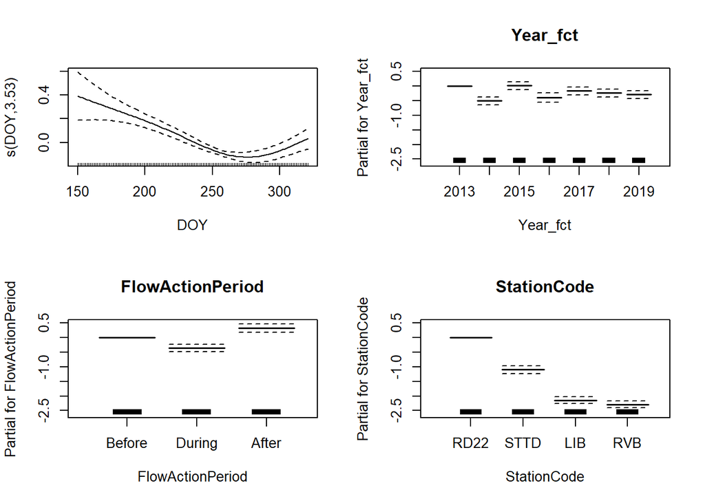

```r
plot(m_gam_cat2, pages = 1, all.terms = TRUE)
```

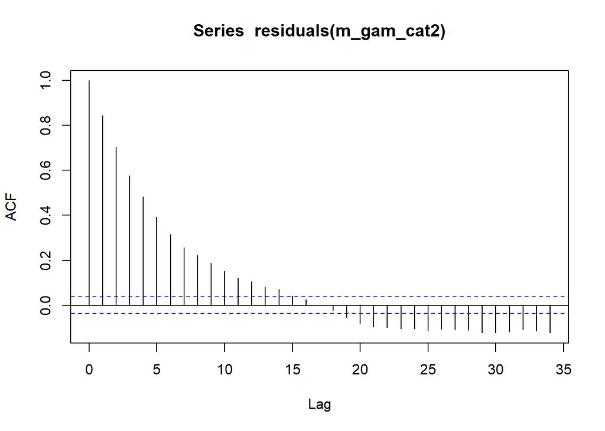

```r
acf(residuals(m_gam_cat2))
```

```r
Box.test(residuals(m_gam_cat2), lag = 20, type = 'Ljung-Box')
```

```
##
##  Box-Ljung test
##
## data:  residuals(m_gam_cat2)
## X-squared = 6617.7, df = 20, p-value < 2.2e-16
```

### Model with AR() correlation structure

Now, we’ll try to deal with the residual autocorrelation. We’ll run AR(1), AR(2), and AR(3) models and compare them using AIC.

```r
# Define model formula as an object
f_gam_cat2 <- as.formula("Chla_log ~ (Year_fct + FlowActionPeriod + StationCode)^2 + s(DOY, k = 5)")

# Fit original model with k = 5 and three successive AR(p) models
m_gamm_cat2 <- gamm(
  f_gam_cat2,
  data = df_chla_wt_c,
  method = "REML"
)

m_gamm_cat2_ar1 <- gamm(
  f_gam_cat2,
  data = df_chla_wt_c,
  correlation = corARMA(form = ~ 1|Year_fct/StationCode, p = 1), # grouped by Year_fct and StationCode
  method = "REML"
)

m_gamm_cat2_ar2 <- gamm(
  f_gam_cat2,
  data = df_chla_wt_c,
  correlation = corARMA(form = ~ 1|Year_fct/StationCode, p = 2), # grouped by Year_fct and StationCode
  method = "REML"
)

m_gamm_cat2_ar3 <- gamm(
  f_gam_cat2,
  data = df_chla_wt_c,
  correlation = corARMA(form = ~ 1|Year_fct/StationCode, p = 3), # grouped by Year_fct and StationCode
  method = "REML"
)

# Compare models
anova(
  m_gamm_cat2$lme,
  m_gamm_cat2_ar1$lme,
  m_gamm_cat2_ar2$lme,
  m_gamm_cat2_ar3$lme
)
```

```
##                     Model df       AIC       BIC    logLik   Test  L.Ratio
## m_gamm_cat2$lme         1 51  2243.041  2547.337 -1070.521
## m_gamm_cat2_ar1$lme     2 52 -1907.890 -1597.627  1005.945 1 vs 2 4152.931
## m_gamm_cat2_ar2$lme     3 53 -1906.021 -1589.792  1006.011 2 vs 3    0.132
## m_gamm_cat2_ar3$lme     4 54 -1905.019 -1582.823  1006.509 3 vs 4    0.998
##                     p-value
## m_gamm_cat2$lme
## m_gamm_cat2_ar1$lme  <.0001
## m_gamm_cat2_ar2$lme  0.7167
## m_gamm_cat2_ar3$lme  0.3179
```

It looks like the AR(1) model has the best fit according to the AIC values and backed up by the BIC values. Let’s take a closer look at that one.

### AR(1) Model

```r
# Pull out the residuals and the GAM model
resid_cat2_ar1 <- residuals(m_gamm_cat2_ar1$lme, type = "normalized")
m_gamm_cat2_ar1_gam <- m_gamm_cat2_ar1$gam

summary(m_gamm_cat2_ar1_gam)
```

```
##
## Family: gaussian
## Link function: identity
##
## Formula:
## Chla_log ~ (Year_fct + FlowActionPeriod + StationCode)^2 + s(DOY,
##     k = 5)
##
## Parametric coefficients:
##                                         Estimate Std. Error t value Pr(>|t|)
## (Intercept)                             9.400509   0.229508  40.959  < 2e-16
## Year_fct2014                           -0.363899   0.299792  -1.214 0.224908
## Year_fct2015                           -0.020134   0.299762  -0.067 0.946453
## Year_fct2016                           -0.536829   0.319613  -1.680 0.093139
## Year_fct2017                           -0.093840   0.297754  -0.315 0.752665
## Year_fct2018                           -0.214040   0.294097  -0.728 0.466802
## Year_fct2019                           -0.142536   0.295918  -0.482 0.630073
## FlowActionPeriodDuring                  0.028091   0.098052   0.286 0.774521
## FlowActionPeriodAfter                   0.319889   0.133116   2.403 0.016320
## StationCodeSTTD                        -0.228035   0.309700  -0.736 0.461602
## StationCodeLIB                         -1.754353   0.287274  -6.107 1.15e-09
## StationCodeRVB                         -1.972157   0.283865  -6.948 4.58e-12
## Year_fct2014:FlowActionPeriodDuring    -0.123204   0.114744  -1.074 0.283035
## Year_fct2015:FlowActionPeriodDuring    -0.078610   0.114363  -0.687 0.491900
## Year_fct2016:FlowActionPeriodDuring    -0.088402   0.116556  -0.758 0.448243
## Year_fct2017:FlowActionPeriodDuring    -0.001409   0.114895  -0.012 0.990214
## Year_fct2018:FlowActionPeriodDuring    -0.126989   0.114737  -1.107 0.268483
## Year_fct2019:FlowActionPeriodDuring    -0.070220   0.115683  -0.607 0.543896
## Year_fct2014:FlowActionPeriodAfter     -0.248509   0.153022  -1.624 0.104482
## Year_fct2015:FlowActionPeriodAfter     -0.119569   0.153648  -0.778 0.436515
## Year_fct2016:FlowActionPeriodAfter     -0.251766   0.158549  -1.588 0.112412
## Year_fct2017:FlowActionPeriodAfter     -0.519339   0.154236  -3.367 0.000769
## Year_fct2018:FlowActionPeriodAfter     -0.345890   0.154314  -2.241 0.025071
## Year_fct2019:FlowActionPeriodAfter     -0.106045   0.154616  -0.686 0.492857
## Year_fct2014:StationCodeSTTD            0.316809   0.411046   0.771 0.440925
## Year_fct2015:StationCodeSTTD           -0.387762   0.400573  -0.968 0.333117
## Year_fct2016:StationCodeSTTD            0.480368   0.420543   1.142 0.253442
## Year_fct2017:StationCodeSTTD           -0.549525   0.432411  -1.271 0.203888
## Year_fct2018:StationCodeSTTD           -0.897047   0.407500  -2.201 0.027791
## Year_fct2019:StationCodeSTTD           -1.320089   0.401163  -3.291 0.001012
```

[output cut: 63 more lines]

```
## FlowActionPeriodDuring:StationCodeLIB
## FlowActionPeriodAfter:StationCodeLIB
## FlowActionPeriodDuring:StationCodeRVB
## FlowActionPeriodAfter:StationCodeRVB
## ---
## Signif. codes:  0 '***' 0.001 '**' 0.01 '*' 0.05 '.' 0.1 ' ' 1
##
## Approximate significance of smooth terms:
##          edf Ref.df    F p-value
## s(DOY) 2.493  2.493 6.19 0.00119 **
## ---
## Signif. codes:  0 '***' 0.001 '**' 0.01 '*' 0.05 '.' 0.1 ' ' 1
##
## R-sq.(adj) =  0.849
##   Scale est. = 0.19107   n = 2932
```

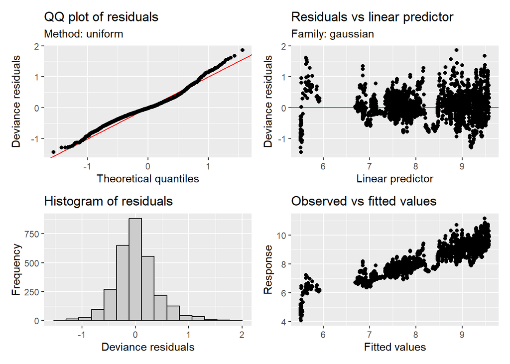

```r
appraise(m_gamm_cat2_ar1_gam)
```

```r
k.check(m_gamm_cat2_ar1_gam)
```

```
##        k'      edf   k-index p-value
## s(DOY)  4 2.492999 0.9032606       0
```

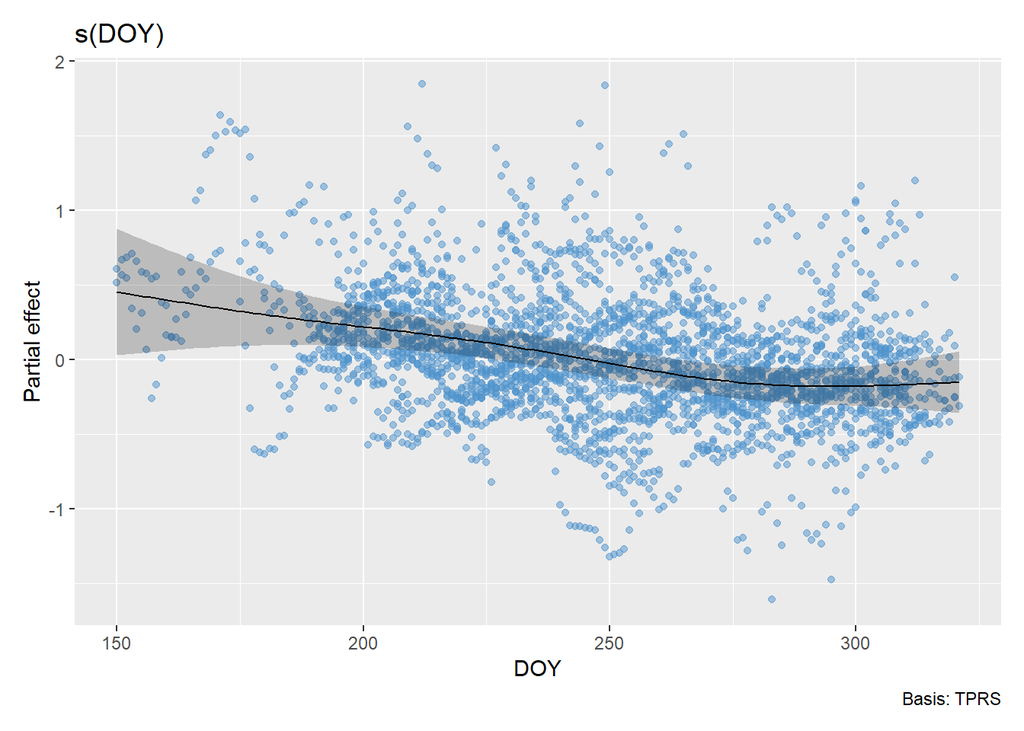

```r
draw(m_gamm_cat2_ar1_gam, select = 1, residuals = TRUE, rug = FALSE)
```

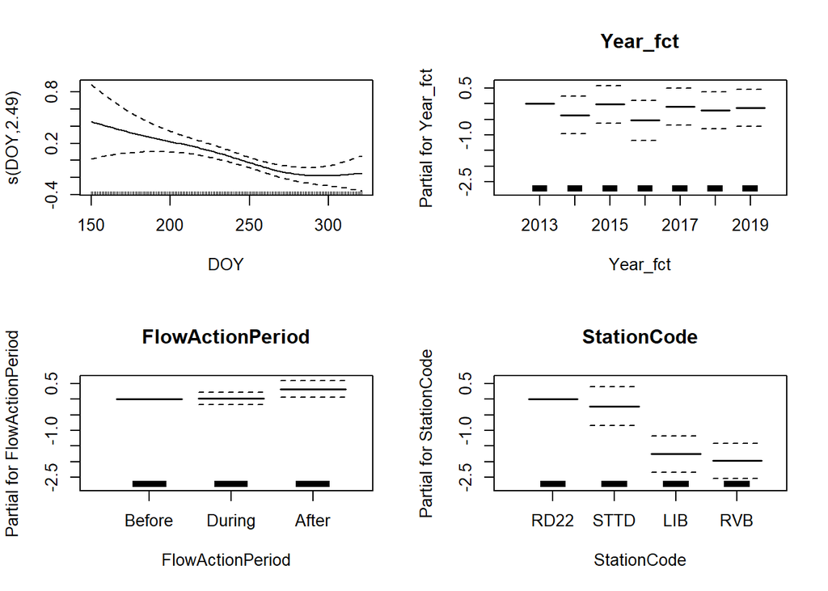

```r
plot(m_gamm_cat2_ar1_gam, pages = 1, all.terms = TRUE)
```

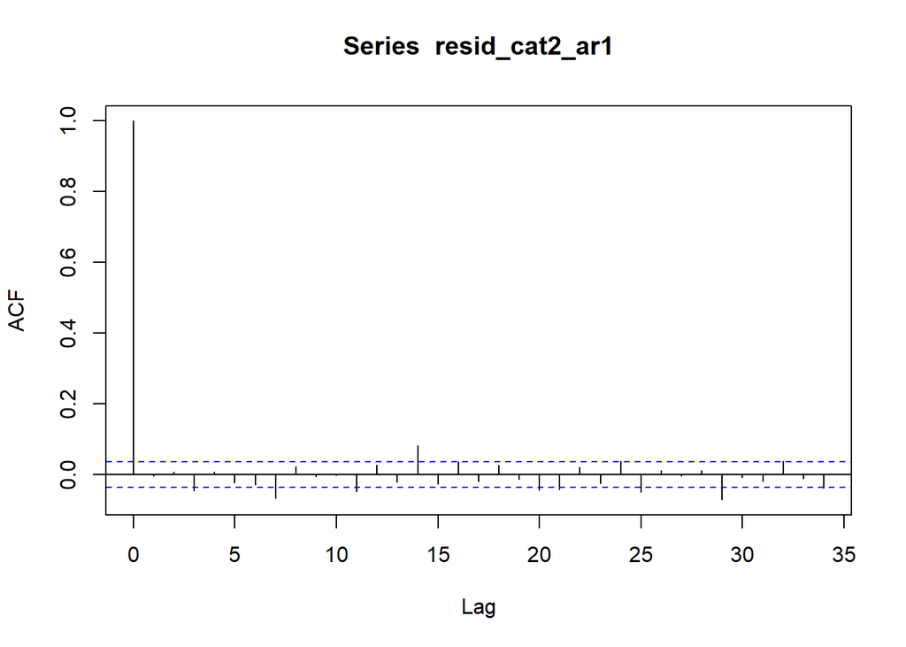

```r
acf(resid_cat2_ar1)
```

```r
Box.test(resid_cat2_ar1, lag = 20, type = 'Ljung-Box')
```

```
##
##  Box-Ljung test
##
## data:  resid_cat2_ar1
## X-squared = 69.446, df = 20, p-value = 2.243e-07
```

The AR(1) model has much less residual autocorrelation, and the diagnostics plots look pretty good. We’ll take a look at the ANOVA table to see if we need all the interaction terms included in the model.

```r
# the anova.gam function is similar to a type 3 ANOVA
anova(m_gamm_cat2_ar1_gam)
```

```
##
## Family: gaussian
## Link function: identity
##
## Formula:
## Chla_log ~ (Year_fct + FlowActionPeriod + StationCode)^2 + s(DOY,
##     k = 5)
##
## Parametric Terms:
##                              df      F  p-value
## Year_fct                      6  0.821  0.55369
## FlowActionPeriod              2  4.643  0.00970
## StationCode                   3 25.306 3.72e-16
## Year_fct:FlowActionPeriod    12  2.563  0.00223
## Year_fct:StationCode         18  5.428 1.03e-12
## FlowActionPeriod:StationCode  6  6.812 3.45e-07
##
## Approximate significance of smooth terms:
##          edf Ref.df    F p-value
## s(DOY) 2.493  2.493 6.19 0.00119
```

All the interaction terms are significant in this model, so we’ll use this one for the model selection process.

```r
rm(m_gam_cat2, m_gamm_cat2, m_gamm_cat2_ar2, m_gamm_cat2_ar3)
```

## Model 5: LM 2-way interactions with water temperature

### Initial Model

We’ll try running a linear model using all two-way interactions between Year, Flow Action Period, and Station, and a covariate of water temperature to account for seasonality and its effect of primary production. First we’ll run the linear model without accounting for serial autocorrelation.

```r
m_lm_cat2_wt <- df_chla_wt_lag %>%
  drop_na(Chla_log, WaterTemp) %>%
  lm(Chla_log ~ (Year_fct + FlowActionPeriod + StationCode)^2 + WaterTemp, data = .)
```

Lets look at the model summary and diagnostics:

```r
summary(m_lm_cat2_wt)
```

```
##
## Call:
## lm(formula = Chla_log ~ (Year_fct + FlowActionPeriod + StationCode)^2 +
##     WaterTemp, data = .)
##
## Residuals:
##      Min       1Q   Median       3Q      Max
## -1.24466 -0.20454 -0.01048  0.18046  1.60342
##
## Coefficients:
##                                         Estimate Std. Error t value Pr(>|t|)
## (Intercept)                             9.593474   0.121134  79.197  < 2e-16
## Year_fct2014                           -0.547554   0.067470  -8.116 7.09e-16
## Year_fct2015                            0.031436   0.068067   0.462 0.644235
## Year_fct2016                           -0.223022   0.071997  -3.098 0.001969
## Year_fct2017                           -0.168358   0.067841  -2.482 0.013133
## Year_fct2018                           -0.231084   0.067214  -3.438 0.000594
## Year_fct2019                           -0.269036   0.067612  -3.979 7.09e-05
## FlowActionPeriodDuring                 -0.508660   0.057813  -8.798  < 2e-16
## FlowActionPeriodAfter                   0.199869   0.064973   3.076 0.002117
## StationCodeSTTD                        -1.107208   0.066171 -16.733  < 2e-16
## StationCodeLIB                         -2.102456   0.060478 -34.764  < 2e-16
## StationCodeRVB                         -2.242817   0.058911 -38.072  < 2e-16
## WaterTemp                               0.005785   0.004457   1.298 0.194396
## Year_fct2014:FlowActionPeriodDuring    -0.391221   0.068867  -5.681 1.47e-08
## Year_fct2015:FlowActionPeriodDuring    -0.255486   0.060197  -4.244 2.26e-05
## Year_fct2016:FlowActionPeriodDuring    -0.324340   0.068169  -4.758 2.05e-06
## Year_fct2017:FlowActionPeriodDuring    -0.265526   0.067783  -3.917 9.16e-05
## Year_fct2018:FlowActionPeriodDuring    -0.123330   0.063191  -1.952 0.051071
## Year_fct2019:FlowActionPeriodDuring    -0.262255   0.064611  -4.059 5.06e-05
## Year_fct2014:FlowActionPeriodAfter     -0.441405   0.060053  -7.350 2.57e-13
## Year_fct2015:FlowActionPeriodAfter     -0.323046   0.059840  -5.399 7.27e-08
## Year_fct2016:FlowActionPeriodAfter     -0.668491   0.064841 -10.310  < 2e-16
## Year_fct2017:FlowActionPeriodAfter     -0.662727   0.060473 -10.959  < 2e-16
## Year_fct2018:FlowActionPeriodAfter     -0.661922   0.061961 -10.683  < 2e-16
## Year_fct2019:FlowActionPeriodAfter     -0.230354   0.060291  -3.821 0.000136
## Year_fct2014:StationCodeSTTD            0.902569   0.074778  12.070  < 2e-16
## Year_fct2015:StationCodeSTTD           -0.256846   0.070606  -3.638 0.000280
## Year_fct2016:StationCodeSTTD            0.702398   0.075613   9.289  < 2e-16
## Year_fct2017:StationCodeSTTD            0.243279   0.083021   2.930 0.003413
```

[output cut: 61 more lines]

```
## Year_fct2017:StationCodeRVB            ***
## Year_fct2018:StationCodeRVB            ***
## Year_fct2019:StationCodeRVB            ***
## FlowActionPeriodDuring:StationCodeSTTD ***
## FlowActionPeriodAfter:StationCodeSTTD  ***
## FlowActionPeriodDuring:StationCodeLIB  ***
## FlowActionPeriodAfter:StationCodeLIB   *
## FlowActionPeriodDuring:StationCodeRVB  ***
## FlowActionPeriodAfter:StationCodeRVB
## ---
## Signif. codes:  0 '***' 0.001 '**' 0.01 '*' 0.05 '.' 0.1 ' ' 1
##
## Residual standard error: 0.3409 on 2879 degrees of freedom
## Multiple R-squared:  0.8889, Adjusted R-squared:  0.8871
## F-statistic:   480 on 48 and 2879 DF,  p-value: < 2.2e-16
```

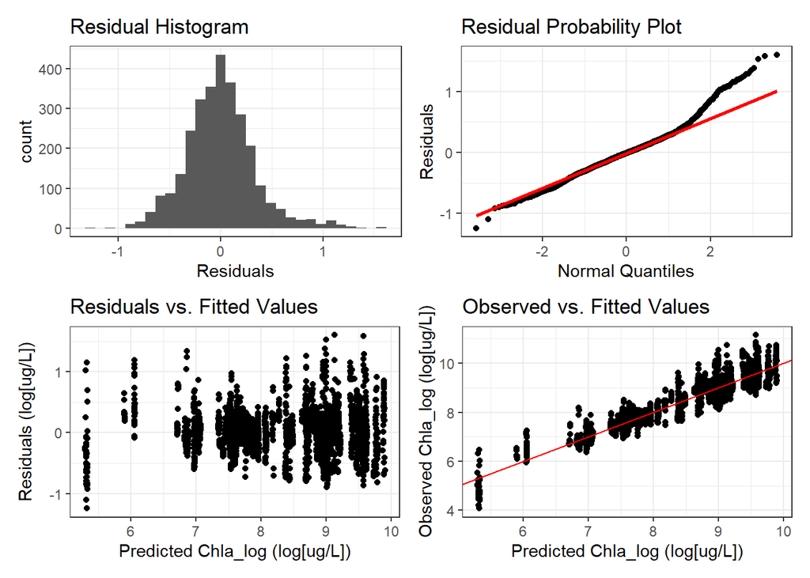

```r
df_chla_wt_lag %>%
  drop_na(Chla_log, WaterTemp) %>%
  plot_lm_diag(
    Chla_log,
    "ug/L",
    m_lm_cat2_wt,
    trans = "log"
  )
```

```r
shapiro.test(m_lm_cat2_wt$residuals)
```

```
##
##  Shapiro-Wilk normality test
##
## data:  m_lm_cat2_wt$residuals
## W = 0.97383, p-value < 2.2e-16
```

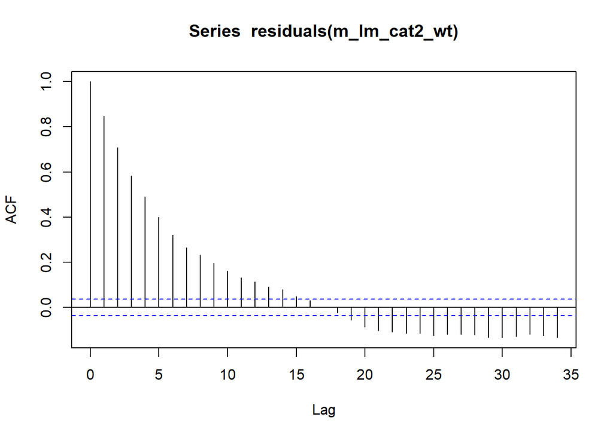

```r
acf(residuals(m_lm_cat2_wt))
```

```r
Box.test(residuals(m_lm_cat2_wt), lag = 20, type = 'Ljung-Box')
```

```
##
##  Box-Ljung test
##
## data:  residuals(m_lm_cat2_wt)
## X-squared = 6771.9, df = 20, p-value < 2.2e-16
```

Hmmm, the residuals deviate from a normal distribution according to visual inspection and the Shapiro-Wilk normality test. Also, the residuals are autocorrelated.